# train_tag

Patricia Yin

09/02/2021

```r
library(ggplot2)
library(glmnet)
library(tidyverse)
library(randomForest)
```

# I. Exploratory Data Analysis

load and view train_tag.csv dataset provided by a Chinese bank in a modelling competition.

```r
tag <- read.csv("../data/train_tag.csv")
dim(tag)[1]
```

```
## [1] 40000
```

```r
colnames(tag)
```

```
##  [1] "id"                              "flag"
##  [3] "gdr_cd"                          "age"
##  [5] "mrg_situ_cd"                     "edu_deg_cd"
##  [7] "acdm_deg_cd"                     "deg_cd"
##  [9] "job_year"                        "ic_ind"
## [11] "fr_or_sh_ind"                    "dnl_mbl_bnk_ind"
## [13] "dnl_bind_cmb_lif_ind"            "hav_car_grp_ind"
## [15] "hav_hou_grp_ind"                 "l6mon_agn_ind"
## [17] "frs_agn_dt_cnt"                  "vld_rsk_ases_ind"
## [19] "fin_rsk_ases_grd_cd"             "confirm_rsk_ases_lvl_typ_cd"
## [21] "cust_inv_rsk_endu_lvl_cd"        "l6mon_daim_aum_cd"
## [23] "tot_ast_lvl_cd"                  "pot_ast_lvl_cd"
## [25] "bk1_cur_year_mon_avg_agn_amt_cd" "l12mon_buy_fin_mng_whl_tms"
## [27] "l12_mon_fnd_buy_whl_tms"         "l12_mon_insu_buy_whl_tms"
## [29] "l12_mon_gld_buy_whl_tms"         "loan_act_ind"
## [31] "pl_crd_lmt_cd"                   "ovd_30d_loan_tot_cnt"
## [33] "his_lng_ovd_day"                 "hld_crd_card_grd_cd"
## [35] "crd_card_act_ind"                "l1y_crd_card_csm_amt_dlm_cd"
## [37] "atdd_type"                       "perm_crd_lmt_cd"
## [39] "cur_debit_cnt"                   "cur_credit_cnt"
## [41] "cur_debit_min_opn_dt_cnt"        "cur_credit_min_opn_dt_cnt"
## [43] "cur_debit_crd_lvl"
```

```r
rdm.index <- sample(dim(tag)[1], size=6)
tag[rdm.index,]
```

```
##             id flag gdr_cd age mrg_situ_cd edu_deg_cd acdm_deg_cd deg_cd
## 36879   U38490    0      M  49           B          A           C      ~
## 26860   U29127    0      F  41           B          B          30      B
## 38923   U34597    0      M  52           B          B          30
## 23437  U984987    1      M  38           B          C          31      ~
## 22181 U1298091    1      M  30           B          F           G      ~
## 24550   U18518    0      F  46           A          B          30
##       job_year ic_ind fr_or_sh_ind dnl_mbl_bnk_ind dnl_bind_cmb_lif_ind
## 36879        0      0            1               1                    0
## 26860        7      1            1               1                    1
## 38923       26      0            0               1                    0
## 23437        0      0            1               1                    1
## 22181        0      0            0               1                    1
## 24550        2      0            0               1                    1
##       hav_car_grp_ind hav_hou_grp_ind l6mon_agn_ind frs_agn_dt_cnt
```

[output cut: 62 more lines]

```r
summary(tag)
```

```
##       id                 flag        gdr_cd               age
##  Length:40000       Min.   :0.0   Length:40000       Min.   : 19.00
##  Class :character   1st Qu.:0.0   Class :character   1st Qu.: 38.00
##  Mode  :character   Median :0.0   Mode  :character   Median : 42.00
##                     Mean   :0.1                      Mean   : 42.99
##                     3rd Qu.:0.0                      3rd Qu.: 48.00
##                     Max.   :1.0                      Max.   :119.00
##  mrg_situ_cd         edu_deg_cd        acdm_deg_cd           deg_cd
##  Length:40000       Length:40000       Length:40000       Length:40000
##  Class :character   Class :character   Class :character   Class :character
##  Mode  :character   Mode  :character   Mode  :character   Mode  :character
##
##
##
##     job_year          ic_ind        fr_or_sh_ind    dnl_mbl_bnk_ind
##  Min.   : 0.000   Min.   :0.0000   Min.   :0.0000   Min.   :0.0000
##  1st Qu.: 0.000   1st Qu.:0.0000   1st Qu.:0.0000   1st Qu.:1.0000
##  Median : 1.000   Median :0.0000   Median :0.0000   Median :1.0000
##  Mean   : 4.449   Mean   :0.1469   Mean   :0.3028   Mean   :0.9996
##  3rd Qu.: 6.000   3rd Qu.:0.0000   3rd Qu.:1.0000   3rd Qu.:1.0000
##  Max.   :90.000   Max.   :1.0000   Max.   :1.0000   Max.   :1.0000
##  dnl_bind_cmb_lif_ind hav_car_grp_ind  hav_hou_grp_ind   l6mon_agn_ind
##  Min.   :0.0000       Min.   :0.0000   Min.   :0.00000   Min.   :0.0000
##  1st Qu.:1.0000       1st Qu.:0.0000   1st Qu.:0.00000   1st Qu.:0.0000
##  Median :1.0000       Median :1.0000   Median :0.00000   Median :0.0000
##  Mean   :0.8361       Mean   :0.6486   Mean   :0.09225   Mean   :0.3259
##  3rd Qu.:1.0000       3rd Qu.:1.0000   3rd Qu.:0.00000   3rd Qu.:1.0000
##  Max.   :1.0000       Max.   :1.0000   Max.   :1.00000   Max.   :1.0000
##  frs_agn_dt_cnt vld_rsk_ases_ind fin_rsk_ases_grd_cd
##  Min.   :  -1   Min.   :0.0000   Min.   :-1.0000
##  1st Qu.:  -1   1st Qu.:0.0000   1st Qu.:-1.0000
##  Median : 186   Median :0.0000   Median :-1.0000
##  Mean   : 493   Mean   :0.4878   Mean   : 0.8276
##  3rd Qu.:1166   3rd Qu.:1.0000   3rd Qu.: 3.0000
##  Max.   :1278   Max.   :1.0000   Max.   :10.0000
##  confirm_rsk_ases_lvl_typ_cd cust_inv_rsk_endu_lvl_cd l6mon_daim_aum_cd
##  Min.   :-1.00               Min.   :1.000            Min.   :1.000
##  1st Qu.:-1.00               1st Qu.:1.000            1st Qu.:2.000
##  Median : 2.00               Median :1.000            Median :3.000
##  Mean   : 1.31               Mean   :2.125            Mean   :3.535
```

[output cut: 36 more lines]

```
##  Max.   :5.000                                  Max.   : 8.000
##  cur_debit_cnt     cur_credit_cnt   cur_debit_min_opn_dt_cnt
##  Min.   :  1.000   Min.   : 1.000   Min.   :   2
##  1st Qu.:  1.000   1st Qu.: 1.000   1st Qu.:2362
##  Median :  2.000   Median : 1.000   Median :4232
##  Mean   :  3.591   Mean   : 1.703   Mean   :4027
##  3rd Qu.:  4.000   3rd Qu.: 2.000   3rd Qu.:5629
##  Max.   :558.000   Max.   :60.000   Max.   :9663
##  cur_credit_min_opn_dt_cnt cur_debit_crd_lvl
##  Min.   :  -1              Min.   :10.0
##  1st Qu.:1713              1st Qu.:10.0
##  Median :3468              Median :20.0
##  Mean   :3128              Mean   :21.1
##  3rd Qu.:4564              3rd Qu.:20.0
##  Max.   :6086              Max.   :80.0
```

## 1.1 Data cleaning and prepocessing

```r
#put categorical variables as fators
tag[c(2,3,5,6,7,8,10,11,12,13,14,15,16,18,30,35,37)] <- lapply(tag[c(2,3,5,6,7,8,10,11,12,13,14,15,16,18,30,35,37)], as.factor)
```

columns with -1: frs_agn_dt_cnt, fin_rsk_ases_grd_cd, confirm_rsk_ases_lvl_typ_cd, tot_ast_lvl_cd, pot_ast_lvl_cd, hld_crd_card_grd_cd, perm_crd_lmt_cd, cur_credit_min_opn_dt_cnt

Treat them as missing values and remove rows with -1 in any columns from the dataset

```r
#try to remove -1
colnames(tag)
```

```
##  [1] "id"                              "flag"
##  [3] "gdr_cd"                          "age"
##  [5] "mrg_situ_cd"                     "edu_deg_cd"
##  [7] "acdm_deg_cd"                     "deg_cd"
##  [9] "job_year"                        "ic_ind"
## [11] "fr_or_sh_ind"                    "dnl_mbl_bnk_ind"
## [13] "dnl_bind_cmb_lif_ind"            "hav_car_grp_ind"
## [15] "hav_hou_grp_ind"                 "l6mon_agn_ind"
## [17] "frs_agn_dt_cnt"                  "vld_rsk_ases_ind"
## [19] "fin_rsk_ases_grd_cd"             "confirm_rsk_ases_lvl_typ_cd"
## [21] "cust_inv_rsk_endu_lvl_cd"        "l6mon_daim_aum_cd"
## [23] "tot_ast_lvl_cd"                  "pot_ast_lvl_cd"
## [25] "bk1_cur_year_mon_avg_agn_amt_cd" "l12mon_buy_fin_mng_whl_tms"
## [27] "l12_mon_fnd_buy_whl_tms"         "l12_mon_insu_buy_whl_tms"
## [29] "l12_mon_gld_buy_whl_tms"         "loan_act_ind"
## [31] "pl_crd_lmt_cd"                   "ovd_30d_loan_tot_cnt"
## [33] "his_lng_ovd_day"                 "hld_crd_card_grd_cd"
## [35] "crd_card_act_ind"                "l1y_crd_card_csm_amt_dlm_cd"
## [37] "atdd_type"                       "perm_crd_lmt_cd"
## [39] "cur_debit_cnt"                   "cur_credit_cnt"
## [41] "cur_debit_min_opn_dt_cnt"        "cur_credit_min_opn_dt_cnt"
## [43] "cur_debit_crd_lvl"
```

```r
neg_col_index <- c(17, 19, 20, 23, 24, 34, 38, 42)
dat <- tag
for (i in 1:8) {
  dat <- subset(dat, dat[neg_col_index[i]] != -1)
}

dim(dat)
```

```
## [1] 4629   43
```

```r
dim(tag)
```

```
## [1] 40000    43
```

The reduced dataset is only 1/10 of the original one. Try to investigate why -1 was coded

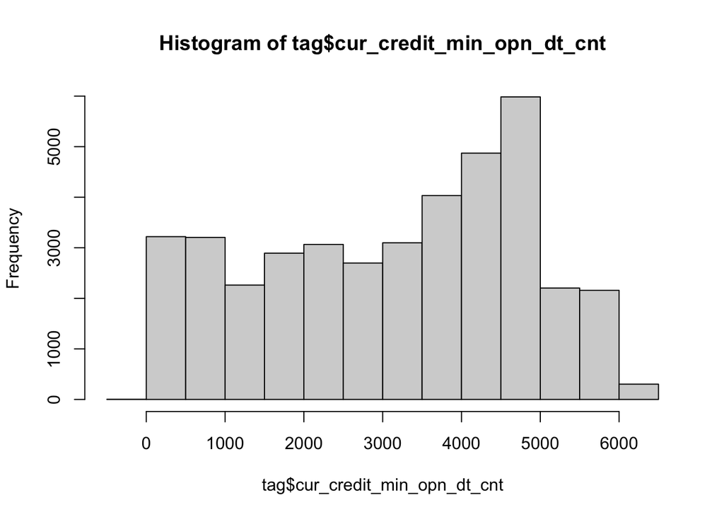

```r
#check cur_credit_min_opn_dt_cnt
hist(tag$cur_credit_min_opn_dt_cnt)
```

```r
summary(tag$cur_credit_cnt)
```

```
##    Min. 1st Qu.  Median    Mean 3rd Qu.    Max.
##   1.000   1.000   1.000   1.703   2.000  60.000
```

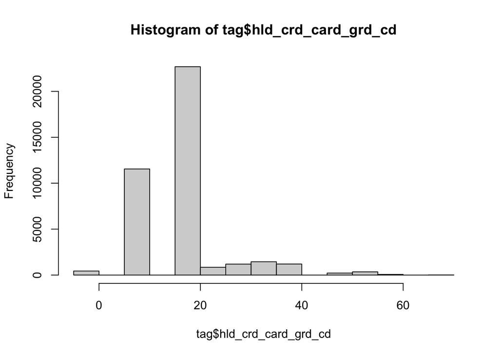

```r
#remove rows with -1 in cur_credit_min_opn_dt_cnt
dat1 <- subset(tag, cur_credit_min_opn_dt_cnt != -1)

#check hld_crd_card_grd_cd
hist(tag$hld_crd_card_grd_cd)
```

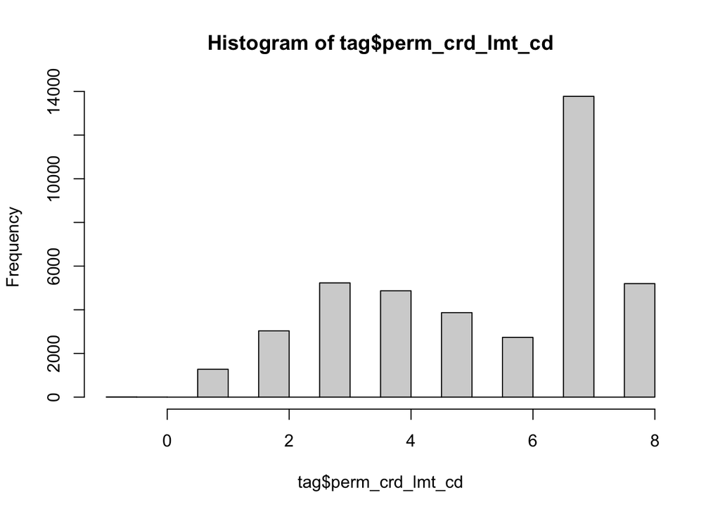

```r
#remove -1 in hld_crd_card_grd_cd
dat1 <- subset(dat1, hld_crd_card_grd_cd != -1)

#check perm_crd_lmt_cd
hist(tag$perm_crd_lmt_cd)
```

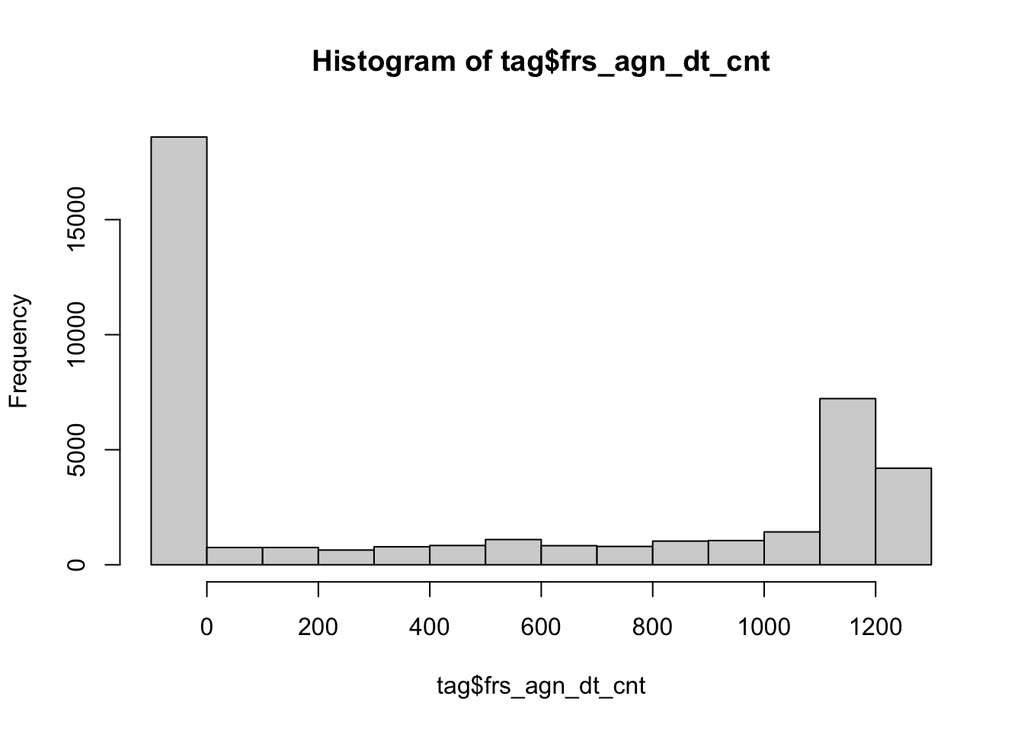

```r
#remove -1 in perm_crd_lmt_cd
dat1 <- subset(dat1, perm_crd_lmt_cd != -1)

#check frs_agn_dt_cnt
hist(tag$frs_agn_dt_cnt)
```

```r
summary(tag$l6mon_agn_ind)
```

```
##     0     1
## 26965 13035
```

```r
length(which(tag$frs_agn_dt_cnt == -1)) #=18588
```

```
## [1] 18588
```

```r
length(which(tag$frs_agn_dt_cnt == -1 & tag$l6mon_agn_ind == 0)) #=18528
```

```
## [1] 18528
```

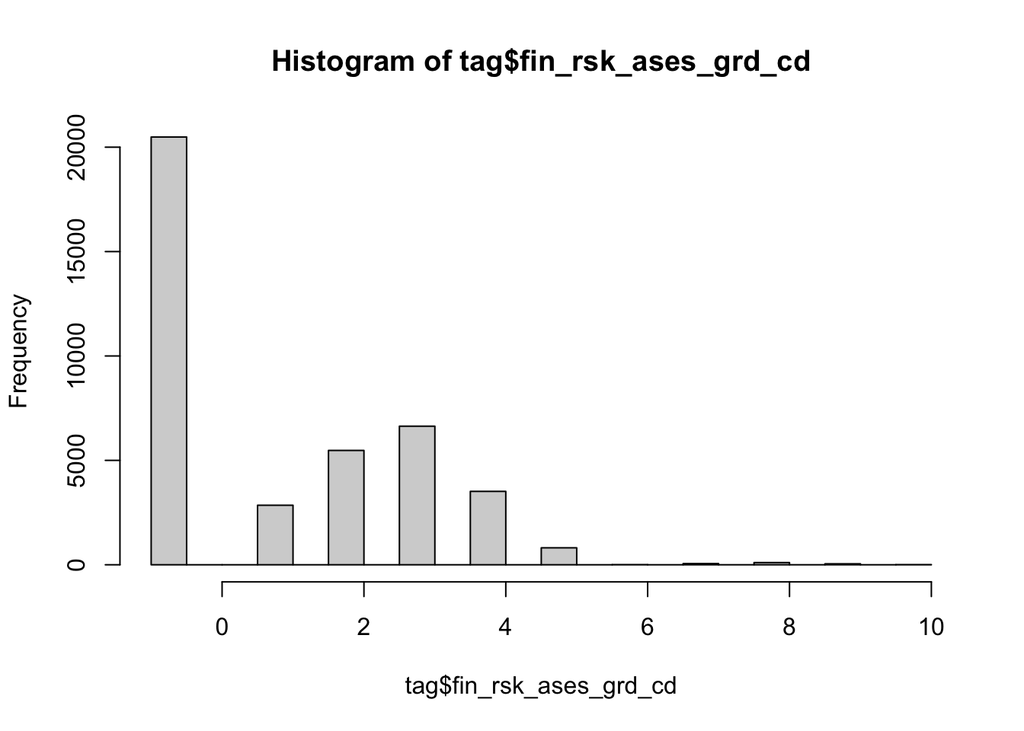

```r
#remove frs_agn_dt_cnt
dat1 <- subset(dat1, select = - frs_agn_dt_cnt)

#check fin_rsk_ases_grd_cd
hist(tag$fin_rsk_ases_grd_cd)
```

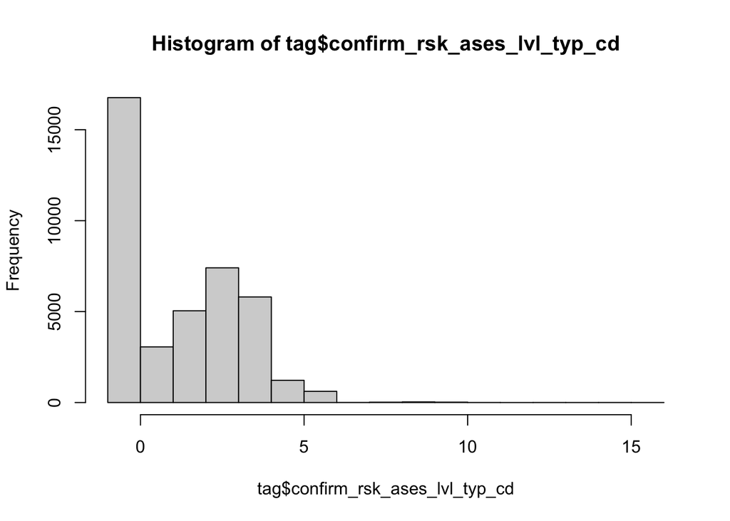

```r
#code the variable as a factor
dat1$fin_rsk_ases_grd_cd <- as.factor(dat1$fin_rsk_ases_grd_cd)

#check confirm_rsk_ases_lvl_typ_cd
hist(tag$confirm_rsk_ases_lvl_typ_cd)
```

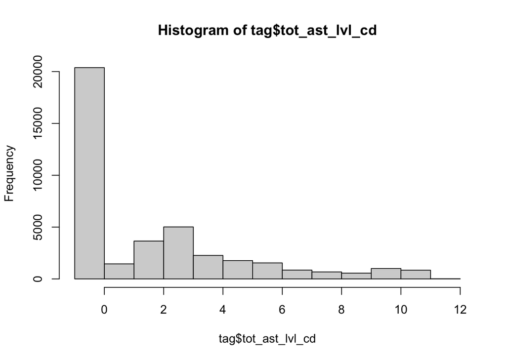

```r
#code the variable as a factor
dat1$confirm_rsk_ases_lvl_typ_cd <- as.factor(dat1$confirm_rsk_ases_lvl_typ_cd)

#check tot_ast_lvl_cd
hist(tag$tot_ast_lvl_cd)
```

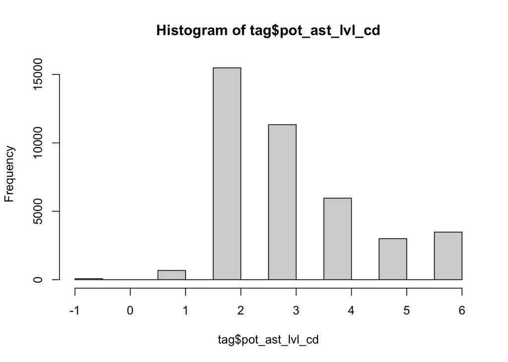

```r
#code the variable as a factor
dat1$tot_ast_lvl_cd <- as.factor(dat1$tot_ast_lvl_cd)

#check pot_ast_lvl_cd
hist(tag$pot_ast_lvl_cd)
```

```r
#code the variable as a factor
dat1$pot_ast_lvl_cd <- as.factor(dat1$pot_ast_lvl_cd)

#code "" levels as "-1"
levels(tag$atdd_type) <- c("-1", "-1", "0", "1")
levels(tag$deg_cd) <- c("-1",  "~", "A", "B", "C", "D", "E", "Z")
levels(tag$edu_deg_cd) <- c("-1",  "~", "A", "B", "C", "D", "E", "F", "G", "J", "K", "L", "M", "Z")
```

modify response variable:

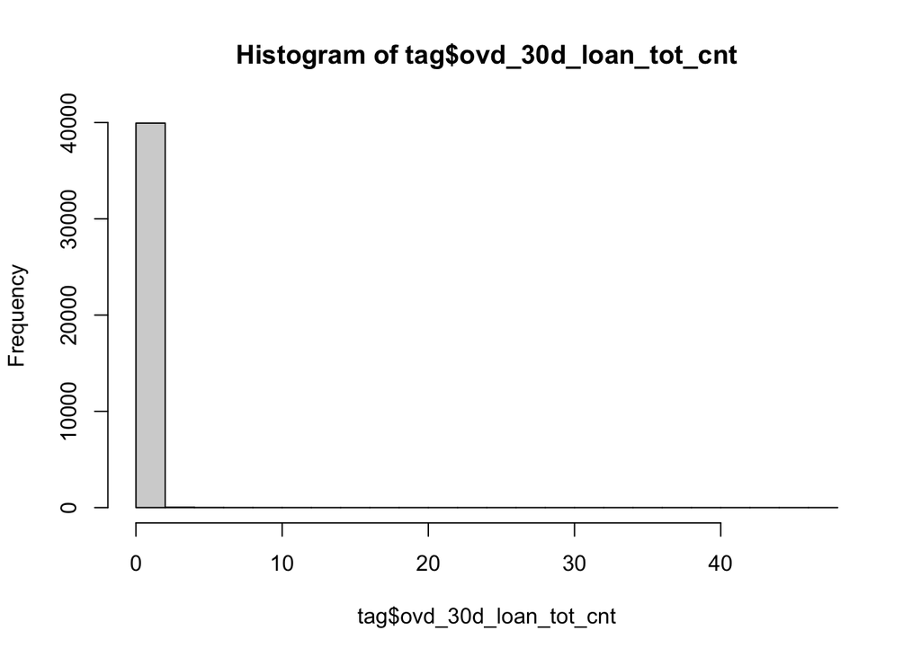

```r
#response variable
hist(tag$ovd_30d_loan_tot_cnt)
```

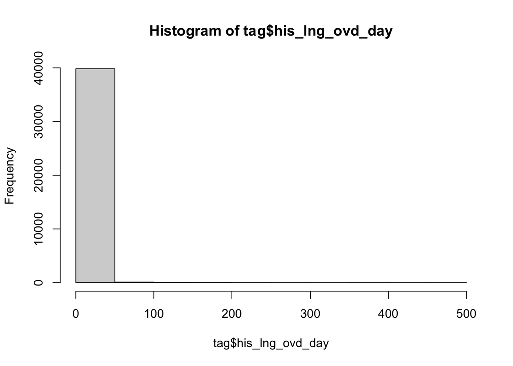

```r
#default for loan + credit card
hist(tag$his_lng_ovd_day)
```

```r
length(which(tag$his_lng_ovd_day != 0))
```

```
## [1] 3044
```

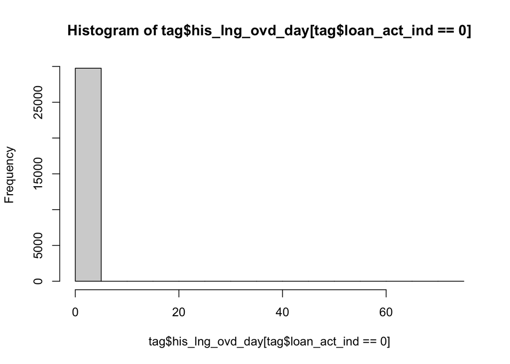

```r
#default for credit card (customers without loan)
hist(tag$his_lng_ovd_day[tag$loan_act_ind==0])
```

```r
#try to exclude customers with loan
dat1.1 <- dat1[dat1$loan_act_ind==0,]
length(which(dat1.1$his_lng_ovd_day > 0)) #only 3
```

```
## [1] 3
```

```r
length(which(dat1.1$ovd_30d_loan_tot_cnt > 0)) #only 1 person
```

```
## [1] 1
```

```r
#define Good as customers who never default
dat1$good <- ifelse(dat1$his_lng_ovd_day == 0, 1, 0) #Good as 1, Bad as 0
```

identify our target group: married women under 35

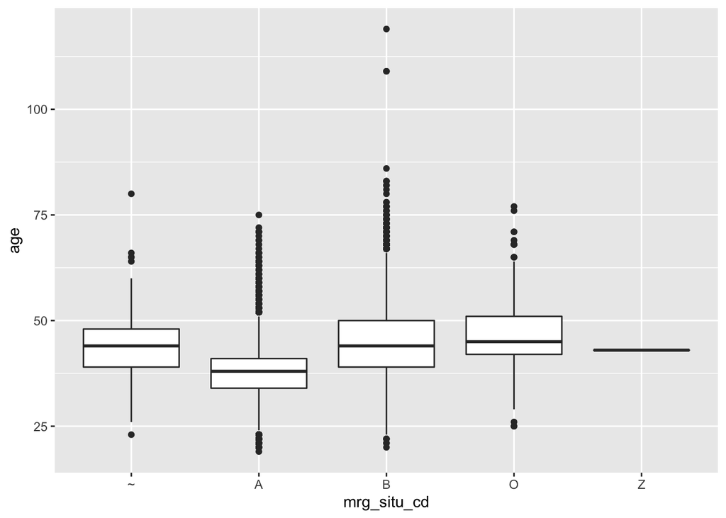

```r
#investigate mrg_situ_cd
ggplot(dat1, aes(x=mrg_situ_cd, y=age)) + geom_boxplot()
```

```r
attach(dat1)
mean(age[mrg_situ_cd=="A" & gdr_cd == "M"])
```

```
## [1] 36.48186
```

```r
mean(age[mrg_situ_cd=="B" & gdr_cd == "M"])
```

```
## [1] 44.8465
```

```r
detach()
#assume A = single, B = married

#subset our target group
dat.t <- subset(dat1, age<=35 & gdr_cd=="F" & mrg_situ_cd=="B", select = -c(age, gdr_cd, mrg_situ_cd))
dim(dat.t)
```

```
## [1] 856  40
```

```r
summary(dat.t)
```

```
##       id            flag      edu_deg_cd  acdm_deg_cd     deg_cd
##  Length:856         0:574   B      :244   30:195      ~      :532
##  Class :character   1:282   C      :209   31:276             :263
##  Mode  :character           F      :168   C : 32      A      : 29
##                             K      :120   D :  2      B      : 17
##                             Z      : 52   F : 32      C      :  9
##                             A      : 33   G :246      Z      :  6
##                             (Other): 30   Z : 73      (Other):  0
##     job_year      ic_ind  fr_or_sh_ind dnl_mbl_bnk_ind dnl_bind_cmb_lif_ind
##  Min.   : 0.000   0:798   0:687        0:  0           0: 81
##  1st Qu.: 0.000   1: 58   1:169        1:856           1:775
##  Median : 1.000
##  Mean   : 2.116
##  3rd Qu.: 3.000
##  Max.   :20.000
##
##  hav_car_grp_ind hav_hou_grp_ind l6mon_agn_ind vld_rsk_ases_ind
##  0:326           0:812           0:631         0:480
##  1:530           1: 44           1:225         1:376
##
##
##
##
##
##  fin_rsk_ases_grd_cd confirm_rsk_ases_lvl_typ_cd cust_inv_rsk_endu_lvl_cd
##  -1     :480         -1     :371                 Min.   :1.000
##  2      :132         2      :163                 1st Qu.:1.000
##  1      :126         1      :131                 Median :1.000
##  3      : 89         3      :128                 Mean   :1.569
##  4      : 26         4      : 53                 3rd Qu.:1.000
##  5      :  3         5      :  8                 Max.   :9.000
##  (Other):  0         (Other):  2
##  l6mon_daim_aum_cd tot_ast_lvl_cd pot_ast_lvl_cd
##  Min.   :1.00      -1     :495    -1:  5
##  1st Qu.:1.00      2      :114    1 :  7
##  Median :2.00      3      : 89    2 :203
##  Mean   :2.39      1      : 43    3 :222
##  3rd Qu.:3.00      4      : 34    4 :193
##  Max.   :9.00      5      : 29    5 :135
##                    (Other): 52    6 : 91
```

[output cut: 33 more lines]

```
##  Min.   :1.00    Min.   : 1.00   Min.   : 1.00   Min.   :  12.0
##  1st Qu.:3.00    1st Qu.: 1.00   1st Qu.: 1.00   1st Qu.: 902.2
##  Median :5.00    Median : 2.00   Median : 1.00   Median :2168.0
##  Mean   :4.71    Mean   : 2.02   Mean   : 1.63   Mean   :2312.7
##  3rd Qu.:7.00    3rd Qu.: 2.00   3rd Qu.: 2.00   3rd Qu.:3582.5
##  Max.   :8.00    Max.   :24.00   Max.   :10.00   Max.   :7986.0
##
##  cur_credit_min_opn_dt_cnt cur_debit_crd_lvl      good
##  Min.   :   1              Min.   :10.00     Min.   :0.0000
##  1st Qu.: 832              1st Qu.:10.00     1st Qu.:1.0000
##  Median :1748              Median :10.00     Median :1.0000
##  Mean   :2023              Mean   :15.82     Mean   :0.9614
##  3rd Qu.:3202              3rd Qu.:20.00     3rd Qu.:1.0000
##  Max.   :5629              Max.   :80.00     Max.   :1.0000
##
```

```r
#compare characteristics with the main group
summary(tag$dnl_mbl_bnk_ind) #99.96%
```

```
##     0     1
##    15 39985
```

```r
summary(tag$dnl_bind_cmb_lif_ind) #83.61%
```

```
##     0     1
##  6556 33444
```

```r
summary(tag$crd_card_act_ind) #84.765%
```

```
##     0     1
##  6094 33906
```

Some conclusions can be drawn from this summary:

- our target group is very active in digital banking: they have all downloaded the bank’s app (variable dnl_mbl_bnk_ind), 90.5% of them have downloaded the special app for credit card (variable dnl_bind_cmb_lif_ind)
- 85.9% of them are active credit card users (indicated by the variable crd_card_act_ind). However, only 16.4% of them have loans with CMB.
- 3.85% of them have defaulted, much smaller than the proportion that defaulted in the overall dataset (7.57%)

Some variables are highly skewed

- bk1_cur_year_mon_avg_agn_amt_cd
- l12mon_buy_fin_mng_whl_tms
- l12_mon_fnd_buy_whl_tms
- l12_mon_insu_buy_whl_tms
- l12_mon_gld_buy_whl_tms

```r
#investigate some outliers in variables
which.max(dat.t$cur_credit_cnt) #143
```

```
## [1] 143
```

```r
dat.t[143,]
```

```
##          id flag edu_deg_cd acdm_deg_cd deg_cd job_year ic_ind fr_or_sh_ind
## 6991 U34630    0          A           C      ~        0      1            1
##      dnl_mbl_bnk_ind dnl_bind_cmb_lif_ind hav_car_grp_ind hav_hou_grp_ind
## 6991               1                    1               1               0
##      l6mon_agn_ind vld_rsk_ases_ind fin_rsk_ases_grd_cd
## 6991             1                1                   3
##      confirm_rsk_ases_lvl_typ_cd cust_inv_rsk_endu_lvl_cd l6mon_daim_aum_cd
## 6991                           3                        5                 8
##      tot_ast_lvl_cd pot_ast_lvl_cd bk1_cur_year_mon_avg_agn_amt_cd
## 6991              4              1                               5
##      l12mon_buy_fin_mng_whl_tms l12_mon_fnd_buy_whl_tms
## 6991                         57                       1
##      l12_mon_insu_buy_whl_tms l12_mon_gld_buy_whl_tms loan_act_ind
## 6991                        0                       0            1
##      pl_crd_lmt_cd ovd_30d_loan_tot_cnt his_lng_ovd_day hld_crd_card_grd_cd
## 6991             5                    0               0                  60
##      crd_card_act_ind l1y_crd_card_csm_amt_dlm_cd atdd_type perm_crd_lmt_cd
## 6991                1                           5         0               8
##      cur_debit_cnt cur_credit_cnt cur_debit_min_opn_dt_cnt
## 6991             6             10                     4229
##      cur_credit_min_opn_dt_cnt cur_debit_crd_lvl good
## 6991                      2104                60    1
```

```r
which.max(dat.t$his_lng_ovd_day) #298
```

```
## [1] 298
```

```r
dat.t[298,]
```

```
##             id flag edu_deg_cd acdm_deg_cd deg_cd job_year ic_ind fr_or_sh_ind
## 14623 U1184389    1          C          31      ~        1      0            0
##       dnl_mbl_bnk_ind dnl_bind_cmb_lif_ind hav_car_grp_ind hav_hou_grp_ind
## 14623               1                    0               1               0
##       l6mon_agn_ind vld_rsk_ases_ind fin_rsk_ases_grd_cd
## 14623             0                0                  -1
##       confirm_rsk_ases_lvl_typ_cd cust_inv_rsk_endu_lvl_cd l6mon_daim_aum_cd
## 14623                          -1                        1                 1
##       tot_ast_lvl_cd pot_ast_lvl_cd bk1_cur_year_mon_avg_agn_amt_cd
## 14623             -1              2                               0
##       l12mon_buy_fin_mng_whl_tms l12_mon_fnd_buy_whl_tms
## 14623                          0                       0
##       l12_mon_insu_buy_whl_tms l12_mon_gld_buy_whl_tms loan_act_ind
## 14623                        0                       0            1
##       pl_crd_lmt_cd ovd_30d_loan_tot_cnt his_lng_ovd_day hld_crd_card_grd_cd
## 14623             4                    2             165                  10
##       crd_card_act_ind l1y_crd_card_csm_amt_dlm_cd atdd_type perm_crd_lmt_cd
## 14623                1                           5                         7
##       cur_debit_cnt cur_credit_cnt cur_debit_min_opn_dt_cnt
## 14623             7              1                     1742
##       cur_credit_min_opn_dt_cnt cur_debit_crd_lvl good
## 14623                      2559                10    0
```

```r
#investigate the highly skewed variables
skew.df <- subset(dat.t, select = c(bk1_cur_year_mon_avg_agn_amt_cd, l12mon_buy_fin_mng_whl_tms,
                                    l12_mon_fnd_buy_whl_tms, l12_mon_insu_buy_whl_tms, l12_mon_gld_buy_whl_tms,
                                    pl_crd_lmt_cd, good))

#combine adjacent levels with similar Weight of Evidence
check_woe <- function(var) {
  tab.var <- table(as.factor(var), good)
  df.var <- as.data.frame.matrix(tab.var)
  df.prop.var <- as.data.frame.matrix(prop.table(tab.var, 1))
  df.var$woe <- log(df.prop.var$"1" / df.prop.var$"0")
  return(df.var)
}

attach(skew.df)
check_woe(bk1_cur_year_mon_avg_agn_amt_cd)
```

```
##     0   1       woe
## 0  27 606 3.1110431
## 1   0   9       Inf
## 2   0  29       Inf
## 3   0  55       Inf
## 4   3  55 2.9087209
## 5   0  39       Inf
## 6   0  22       Inf
## 7   2   5 0.9162907
## 8   1   2 0.6931472
## 10  0   1       Inf
```

```r
check_woe(l12mon_buy_fin_mng_whl_tms)
```

```
##     0   1      woe
## 0  30 730 3.191847
## 1   1  19 2.944439
## 2   0   9      Inf
## 3   0   4      Inf
## 4   1   3 1.098612
## 5   0   1      Inf
## 6   0  10      Inf
## 7   0   5      Inf
## 8   1   7 1.945910
## 9   0   4      Inf
## 10  0   2      Inf
## 11  0   5      Inf
## 12  0   2      Inf
## 13  0   1      Inf
```

[output cut: 16 more lines]

```r
check_woe(l12_mon_fnd_buy_whl_tms)
```

```
##      0   1       woe
## 0   26 618 3.1683919
## 1    1  65 4.1743873
## 2    2  19 2.2512918
## 3    1  14 2.6390573
## 4    0   8       Inf
## 5    0   8       Inf
## 6    0   7       Inf
## 7    0   7       Inf
## 8    0   2       Inf
## 9    0   6       Inf
## 10   0   8       Inf
## 11   0   2       Inf
## 12   0   3       Inf
## 13   0   2       Inf
```

[output cut: 36 more lines]

```r
check_woe(l12_mon_insu_buy_whl_tms)
```

```
##    0   1      woe
## 0 33 815 3.206681
## 1  0   8      Inf
```

```r
#too few people buy insurance （8 people buy once)

check_woe(l12_mon_gld_buy_whl_tms)
```

```
##      0   1      woe
## 0   33 818 3.210355
## 1    0   2      Inf
## 12   0   1      Inf
## 164  0   1      Inf
## 241  0   1      Inf
```

```r
#too few people buy gold (5 people buy >= 1 time)

check_woe(pl_crd_lmt_cd)
```

```
##   0   1       woe
## 0 4 724 5.1984970
## 1 0   1       Inf
## 2 1   4 1.3862944
## 3 8  21 0.9650809
## 4 8  17 0.7537718
## 5 4  38 2.2512918
## 6 7   8 0.1335314
## 7 0   5       Inf
## 8 0   5       Inf
## 9 1   0      -Inf
```

```r
detach()
```

```r
#drop levels
dat.t <- droplevels(dat.t)

#select variables which reflect customer background and behaviour
dat.tf <- subset(dat.t, select = c(cur_debit_cnt, cur_credit_cnt, cur_debit_min_opn_dt_cnt, cur_credit_min_opn_dt_cnt, cur_debit_crd_lvl, hld_crd_card_grd_cd, crd_card_act_ind, l1y_crd_card_csm_amt_dlm_cd, atdd_type, perm_crd_lmt_cd, acdm_deg_cd, job_year, ic_ind, fr_or_sh_ind,
dnl_bind_cmb_lif_ind,
hav_car_grp_ind,
hav_hou_grp_ind,
l6mon_daim_aum_cd,
tot_ast_lvl_cd,
pot_ast_lvl_cd,
l12mon_buy_fin_mng_whl_tms,
l12_mon_fnd_buy_whl_tms,
l12_mon_insu_buy_whl_tms,
l12_mon_gld_buy_whl_tms,
loan_act_ind,
pl_crd_lmt_cd,
good))
```

edu_deg_cd, acdm_deg_cd, deg_cd are similar ideas. pick acdm_deg_cd because it has fewer levels than edu_deg_cd and more even distribution than deg_cd

2. From Initial to Final Model

```r
#raw model
glm.f <- glm(good~., data=dat.tf, family="binomial")
summary(glm.f)
```

```
##
## Call:
## glm(formula = good ~ ., family = "binomial", data = dat.tf)
##
## Deviance Residuals:
##      Min        1Q    Median        3Q       Max
## -2.78118   0.00000   0.00000   0.00001   2.04020
##
## Coefficients:
##                               Estimate Std. Error z value Pr(>|z|)
## (Intercept)                  2.715e+01  3.113e+04   0.001  0.99930
## cur_debit_cnt               -2.590e-01  1.431e-01  -1.810  0.07025 .
## cur_credit_cnt               6.116e-01  4.871e-01   1.256  0.20926
## cur_debit_min_opn_dt_cnt     3.222e-04  3.826e-04   0.842  0.39970
## cur_credit_min_opn_dt_cnt    3.072e-04  4.244e-04   0.724  0.46911
## cur_debit_crd_lvl           -1.460e-02  6.298e-02  -0.232  0.81672
## hld_crd_card_grd_cd         -9.997e-02  5.772e-02  -1.732  0.08330 .
## crd_card_act_ind1            1.146e+00  3.222e+00   0.356  0.72207
## l1y_crd_card_csm_amt_dlm_cd -7.294e-01  6.096e-01  -1.196  0.23150
## atdd_type0                   2.966e+00  1.134e+00   2.615  0.00892 **
## atdd_type1                  -4.710e-01  1.215e+00  -0.388  0.69817
## perm_crd_lmt_cd              2.831e-01  3.741e-01   0.757  0.44932
## acdm_deg_cd31               -2.601e+00  1.346e+00  -1.933  0.05327 .
## acdm_deg_cdC                 1.585e+01  1.021e+04   0.002  0.99876
## acdm_deg_cdD                -6.285e+00  5.278e+04   0.000  0.99990
## acdm_deg_cdF                -4.709e+00  1.929e+00  -2.442  0.01461 *
## acdm_deg_cdG                -3.443e+00  1.523e+00  -2.261  0.02375 *
## acdm_deg_cdZ                -3.729e+00  1.820e+00  -2.049  0.04049 *
## job_year                     2.688e-02  1.382e-01   0.194  0.84582
## ic_ind1                     -1.858e+00  1.421e+00  -1.308  0.19084
## fr_or_sh_ind1                7.623e-01  1.277e+00   0.597  0.55066
## dnl_bind_cmb_lif_ind1       -7.917e-01  1.863e+00  -0.425  0.67085
## hav_car_grp_ind1             7.449e-01  9.267e-01   0.804  0.42155
## hav_hou_grp_ind1            -3.200e+00  1.257e+00  -2.545  0.01093 *
## l6mon_daim_aum_cd            3.577e-01  4.434e-01   0.807  0.41984
## tot_ast_lvl_cd1              3.646e+00  3.598e+00   1.013  0.31086
## tot_ast_lvl_cd2              7.256e-01  1.281e+00   0.566  0.57122
## tot_ast_lvl_cd3              1.301e+00  1.542e+00   0.844  0.39887
## tot_ast_lvl_cd4              1.784e+01  1.013e+04   0.002  0.99859
## tot_ast_lvl_cd5             -3.059e+00  2.402e+00  -1.273  0.20290
```

[output cut: 13 more lines]

```
## l12_mon_fnd_buy_whl_tms     -6.902e-02  4.195e-02  -1.645  0.09989 .
## l12_mon_insu_buy_whl_tms     1.435e+01  1.901e+04   0.001  0.99940
## l12_mon_gld_buy_whl_tms      2.128e-02  2.364e+02   0.000  0.99993
## loan_act_ind1               -2.305e+01  2.238e+03  -0.010  0.99178
## pl_crd_lmt_cd               -1.913e-01  2.402e-01  -0.796  0.42576
## ---
## Signif. codes:  0 '***' 0.001 '**' 0.01 '*' 0.05 '.' 0.1 ' ' 1
##
## (Dispersion parameter for binomial family taken to be 1)
##
##     Null deviance: 279.591  on 855  degrees of freedom
## Residual deviance:  73.738  on 808  degrees of freedom
## AIC: 169.74
##
## Number of Fisher Scoring iterations: 22
```

```r
glm.prob <- predict(glm.f, type="response")
table(ifelse(glm.prob>0.5, 1, 0), dat.tf$good)
```

```
##
##       0   1
##   0  25   5
##   1   8 818
```

```r
# remove variables one by one
glm.1 <- glm(good~ .-pot_ast_lvl_cd, data=dat.tf, family="binomial")
summary(glm.1)
```

```
##
## Call:
## glm(formula = good ~ . - pot_ast_lvl_cd, family = "binomial",
##     data = dat.tf)
##
## Deviance Residuals:
##      Min        1Q    Median        3Q       Max
## -2.92794   0.00000   0.00001   0.00002   1.60127
##
## Coefficients:
##                               Estimate Std. Error z value Pr(>|z|)
## (Intercept)                  2.543e+01  1.522e+03   0.017  0.98667
## cur_debit_cnt               -1.691e-01  1.122e-01  -1.508  0.13167
## cur_credit_cnt               5.903e-01  4.535e-01   1.302  0.19304
## cur_debit_min_opn_dt_cnt     1.772e-04  3.206e-04   0.553  0.58048
## cur_credit_min_opn_dt_cnt    2.121e-04  3.600e-04   0.589  0.55571
## cur_debit_crd_lvl           -2.914e-02  4.973e-02  -0.586  0.55785
## hld_crd_card_grd_cd         -8.943e-02  5.082e-02  -1.760  0.07847 .
## crd_card_act_ind1           -3.341e-01  2.302e+00  -0.145  0.88457
## l1y_crd_card_csm_amt_dlm_cd -5.186e-01  4.743e-01  -1.094  0.27417
## atdd_type0                   2.161e+00  9.006e-01   2.400  0.01640 *
## atdd_type1                  -8.791e-01  1.114e+00  -0.789  0.43002
## perm_crd_lmt_cd              1.713e-02  2.683e-01   0.064  0.94911
## acdm_deg_cd31               -2.140e+00  1.108e+00  -1.932  0.05340 .
## acdm_deg_cdC                 1.555e+01  6.299e+03   0.002  0.99803
## acdm_deg_cdD                -2.172e+00  3.193e+04   0.000  0.99995
## acdm_deg_cdF                -2.918e+00  1.568e+00  -1.861  0.06272 .
## acdm_deg_cdG                -2.465e+00  1.217e+00  -2.026  0.04272 *
## acdm_deg_cdZ                -2.811e+00  1.488e+00  -1.889  0.05889 .
## job_year                     1.218e-02  1.172e-01   0.104  0.91723
## ic_ind1                     -1.800e+00  1.175e+00  -1.531  0.12565
## fr_or_sh_ind1                6.118e-01  1.077e+00   0.568  0.57016
## dnl_bind_cmb_lif_ind1        3.007e-01  1.476e+00   0.204  0.83858
## hav_car_grp_ind1             7.725e-01  7.222e-01   1.070  0.28481
## hav_hou_grp_ind1            -2.567e+00  9.776e-01  -2.626  0.00864 **
## l6mon_daim_aum_cd            4.252e-01  3.736e-01   1.138  0.25505
## tot_ast_lvl_cd1              2.031e+00  2.077e+00   0.978  0.32809
## tot_ast_lvl_cd2              5.590e-01  1.111e+00   0.503  0.61500
## tot_ast_lvl_cd3              1.250e+00  1.344e+00   0.930  0.35237
## tot_ast_lvl_cd4              1.721e+01  6.288e+03   0.003  0.99782
```

[output cut: 8 more lines]

```
## l12_mon_fnd_buy_whl_tms     -4.916e-02  3.230e-02  -1.522  0.12801
## l12_mon_insu_buy_whl_tms     1.463e+01  1.286e+04   0.001  0.99909
## l12_mon_gld_buy_whl_tms      1.324e-02  1.415e+02   0.000  0.99993
## loan_act_ind1               -2.088e+01  1.522e+03  -0.014  0.98906
## pl_crd_lmt_cd               -1.862e-01  2.109e-01  -0.883  0.37725
## ---
## Signif. codes:  0 '***' 0.001 '**' 0.01 '*' 0.05 '.' 0.1 ' ' 1
##
## (Dispersion parameter for binomial family taken to be 1)
##
##     Null deviance: 279.591  on 855  degrees of freedom
## Residual deviance:  83.419  on 814  degrees of freedom
## AIC: 167.42
##
## Number of Fisher Scoring iterations: 21
```

```r
glm.prob <- predict(glm.1, type="response")
tab.1 <- table(ifelse(glm.prob>0.5, 1, 0), dat.tf$good)


glm.2 <- glm(good~ .-pot_ast_lvl_cd - l12_mon_gld_buy_whl_tms, data=dat.tf, family="binomial")
summary(glm.2)
```

```
##
## Call:
## glm(formula = good ~ . - pot_ast_lvl_cd - l12_mon_gld_buy_whl_tms,
##     family = "binomial", data = dat.tf)
##
## Deviance Residuals:
##      Min        1Q    Median        3Q       Max
## -2.92794   0.00000   0.00001   0.00002   1.60127
##
## Coefficients:
##                               Estimate Std. Error z value Pr(>|z|)
## (Intercept)                  2.543e+01  1.523e+03   0.017  0.98668
## cur_debit_cnt               -1.691e-01  1.122e-01  -1.508  0.13167
## cur_credit_cnt               5.903e-01  4.535e-01   1.302  0.19304
## cur_debit_min_opn_dt_cnt     1.772e-04  3.206e-04   0.553  0.58048
## cur_credit_min_opn_dt_cnt    2.121e-04  3.600e-04   0.589  0.55571
## cur_debit_crd_lvl           -2.914e-02  4.973e-02  -0.586  0.55785
## hld_crd_card_grd_cd         -8.943e-02  5.082e-02  -1.760  0.07847 .
## crd_card_act_ind1           -3.341e-01  2.302e+00  -0.145  0.88457
## l1y_crd_card_csm_amt_dlm_cd -5.186e-01  4.743e-01  -1.094  0.27417
## atdd_type0                   2.161e+00  9.006e-01   2.400  0.01640 *
## atdd_type1                  -8.791e-01  1.114e+00  -0.789  0.43002
## perm_crd_lmt_cd              1.713e-02  2.683e-01   0.064  0.94911
## acdm_deg_cd31               -2.140e+00  1.108e+00  -1.932  0.05340 .
## acdm_deg_cdC                 1.600e+01  5.786e+03   0.003  0.99779
## acdm_deg_cdD                -2.174e+00  3.192e+04   0.000  0.99995
## acdm_deg_cdF                -2.918e+00  1.568e+00  -1.861  0.06272 .
## acdm_deg_cdG                -2.465e+00  1.217e+00  -2.026  0.04272 *
## acdm_deg_cdZ                -2.811e+00  1.488e+00  -1.889  0.05889 .
## job_year                     1.218e-02  1.172e-01   0.104  0.91723
## ic_ind1                     -1.800e+00  1.175e+00  -1.531  0.12565
## fr_or_sh_ind1                6.118e-01  1.077e+00   0.568  0.57016
## dnl_bind_cmb_lif_ind1        3.007e-01  1.476e+00   0.204  0.83858
## hav_car_grp_ind1             7.725e-01  7.222e-01   1.070  0.28481
## hav_hou_grp_ind1            -2.567e+00  9.776e-01  -2.626  0.00864 **
## l6mon_daim_aum_cd            4.252e-01  3.736e-01   1.138  0.25505
## tot_ast_lvl_cd1              2.031e+00  2.077e+00   0.978  0.32809
## tot_ast_lvl_cd2              5.590e-01  1.111e+00   0.503  0.61500
## tot_ast_lvl_cd3              1.250e+00  1.344e+00   0.930  0.35237
## tot_ast_lvl_cd4              1.721e+01  6.289e+03   0.003  0.99782
## tot_ast_lvl_cd5             -1.630e+00  1.925e+00  -0.846  0.39729
## tot_ast_lvl_cd6             -2.785e+00  1.524e+00  -1.828  0.06758 .
## tot_ast_lvl_cd7             -5.613e+00  3.406e+00  -1.648  0.09938 .
## tot_ast_lvl_cd8             -2.941e+00  1.940e+04   0.000  0.99988
## tot_ast_lvl_cd9             -2.217e+00  1.593e+04   0.000  0.99989
## tot_ast_lvl_cd10             1.845e+01  1.478e+04   0.001  0.99900
## tot_ast_lvl_cd11             1.840e+01  1.506e+04   0.001  0.99902
## l12mon_buy_fin_mng_whl_tms   3.390e-01  2.760e-01   1.228  0.21947
## l12_mon_fnd_buy_whl_tms     -4.916e-02  3.230e-02  -1.522  0.12801
## l12_mon_insu_buy_whl_tms     1.463e+01  1.288e+04   0.001  0.99909
## loan_act_ind1               -2.088e+01  1.523e+03  -0.014  0.98906
## pl_crd_lmt_cd               -1.862e-01  2.109e-01  -0.883  0.37725
## ---
## Signif. codes:  0 '***' 0.001 '**' 0.01 '*' 0.05 '.' 0.1 ' ' 1
##
## (Dispersion parameter for binomial family taken to be 1)
##
##     Null deviance: 279.591  on 855  degrees of freedom
## Residual deviance:  83.419  on 815  degrees of freedom
## AIC: 165.42
##
## Number of Fisher Scoring iterations: 21
```

```r
glm.prob <- predict(glm.1, type="response")
table(ifelse(glm.prob>0.5, 1, 0), dat.tf$good)
```

```
##
##       0   1
##   0  23   9
##   1  10 814
```

```r
glm.3 <- glm(good~ .-pot_ast_lvl_cd - l12_mon_gld_buy_whl_tms - l12_mon_insu_buy_whl_tms, data=dat.tf, family="binomial")
summary(glm.3)
```

```
##
## Call:
## glm(formula = good ~ . - pot_ast_lvl_cd - l12_mon_gld_buy_whl_tms -
##     l12_mon_insu_buy_whl_tms, family = "binomial", data = dat.tf)
##
## Deviance Residuals:
##      Min        1Q    Median        3Q       Max
## -2.92746   0.00000   0.00001   0.00002   1.60070
##
## Coefficients:
##                               Estimate Std. Error z value Pr(>|z|)
## (Intercept)                  2.544e+01  1.522e+03   0.017  0.98667
## cur_debit_cnt               -1.693e-01  1.122e-01  -1.509  0.13129
## cur_credit_cnt               5.903e-01  4.538e-01   1.301  0.19334
## cur_debit_min_opn_dt_cnt     1.769e-04  3.207e-04   0.551  0.58136
## cur_credit_min_opn_dt_cnt    2.138e-04  3.596e-04   0.595  0.55213
## cur_debit_crd_lvl           -2.913e-02  4.976e-02  -0.585  0.55826
## hld_crd_card_grd_cd         -8.960e-02  5.081e-02  -1.764  0.07781 .
## crd_card_act_ind1           -3.320e-01  2.304e+00  -0.144  0.88543
## l1y_crd_card_csm_amt_dlm_cd -5.194e-01  4.747e-01  -1.094  0.27386
## atdd_type0                   2.161e+00  9.009e-01   2.399  0.01644 *
## atdd_type1                  -8.793e-01  1.114e+00  -0.789  0.43006
## perm_crd_lmt_cd              1.680e-02  2.685e-01   0.063  0.95010
## acdm_deg_cd31               -2.143e+00  1.108e+00  -1.935  0.05304 .
## acdm_deg_cdC                 1.599e+01  5.783e+03   0.003  0.99779
## acdm_deg_cdD                -2.192e+00  3.193e+04   0.000  0.99995
## acdm_deg_cdF                -2.922e+00  1.568e+00  -1.864  0.06229 .
## acdm_deg_cdG                -2.468e+00  1.217e+00  -2.027  0.04264 *
## acdm_deg_cdZ                -2.809e+00  1.489e+00  -1.886  0.05928 .
## job_year                     1.247e-02  1.171e-01   0.106  0.91522
## ic_ind1                     -1.800e+00  1.175e+00  -1.532  0.12550
## fr_or_sh_ind1                6.098e-01  1.077e+00   0.566  0.57141
## dnl_bind_cmb_lif_ind1        3.024e-01  1.477e+00   0.205  0.83773
## hav_car_grp_ind1             7.732e-01  7.224e-01   1.070  0.28447
## hav_hou_grp_ind1            -2.570e+00  9.772e-01  -2.630  0.00853 **
## l6mon_daim_aum_cd            4.258e-01  3.737e-01   1.139  0.25453
## tot_ast_lvl_cd1              2.034e+00  2.079e+00   0.978  0.32787
## tot_ast_lvl_cd2              5.648e-01  1.109e+00   0.509  0.61066
## tot_ast_lvl_cd3              1.253e+00  1.344e+00   0.932  0.35145
## tot_ast_lvl_cd4              1.721e+01  6.288e+03   0.003  0.99782
## tot_ast_lvl_cd5             -1.633e+00  1.925e+00  -0.848  0.39635
## tot_ast_lvl_cd6             -2.789e+00  1.524e+00  -1.830  0.06721 .
## tot_ast_lvl_cd7             -5.623e+00  3.414e+00  -1.647  0.09952 .
## tot_ast_lvl_cd8             -2.952e+00  1.941e+04   0.000  0.99988
## tot_ast_lvl_cd9             -1.307e+00  1.660e+04   0.000  0.99994
## tot_ast_lvl_cd10             1.845e+01  1.479e+04   0.001  0.99900
## tot_ast_lvl_cd11             1.841e+01  1.506e+04   0.001  0.99902
## l12mon_buy_fin_mng_whl_tms   3.412e-01  2.748e-01   1.242  0.21442
## l12_mon_fnd_buy_whl_tms     -4.938e-02  3.221e-02  -1.533  0.12533
## loan_act_ind1               -2.088e+01  1.522e+03  -0.014  0.98906
## pl_crd_lmt_cd               -1.866e-01  2.109e-01  -0.885  0.37611
## ---
## Signif. codes:  0 '***' 0.001 '**' 0.01 '*' 0.05 '.' 0.1 ' ' 1
##
## (Dispersion parameter for binomial family taken to be 1)
##
##     Null deviance: 279.591  on 855  degrees of freedom
## Residual deviance:  83.429  on 816  degrees of freedom
## AIC: 163.43
##
## Number of Fisher Scoring iterations: 21
```

```r
glm.prob <- predict(glm.3, type="response")
table(ifelse(glm.prob>0.5, 1, 0), dat.tf$good)
```

```
##
##       0   1
##   0  23   9
##   1  10 814
```

```r
glm.4 <- glm(good~ .-pot_ast_lvl_cd - l12_mon_gld_buy_whl_tms - l12_mon_insu_buy_whl_tms - loan_act_ind, data=dat.tf, family="binomial")
summary(glm.4)
```

```
##
## Call:
## glm(formula = good ~ . - pot_ast_lvl_cd - l12_mon_gld_buy_whl_tms -
##     l12_mon_insu_buy_whl_tms - loan_act_ind, family = "binomial",
##     data = dat.tf)
##
## Deviance Residuals:
##     Min       1Q   Median       3Q      Max
## -4.2287   0.0076   0.0352   0.0998   1.6410
##
## Coefficients:
##                               Estimate Std. Error z value Pr(>|z|)
## (Intercept)                  8.607e+00  2.004e+00   4.296 1.74e-05 ***
## cur_debit_cnt               -1.605e-01  1.064e-01  -1.509 0.131230
## cur_credit_cnt               5.332e-01  3.664e-01   1.455 0.145600
## cur_debit_min_opn_dt_cnt     5.205e-05  2.570e-04   0.203 0.839518
## cur_credit_min_opn_dt_cnt    1.824e-04  3.228e-04   0.565 0.571940
## cur_debit_crd_lvl           -3.721e-02  4.365e-02  -0.852 0.393939
## hld_crd_card_grd_cd         -9.215e-02  4.517e-02  -2.040 0.041336 *
## crd_card_act_ind1           -8.149e-01  1.923e+00  -0.424 0.671729
## l1y_crd_card_csm_amt_dlm_cd -4.852e-01  3.760e-01  -1.291 0.196871
## atdd_type0                   2.386e+00  8.731e-01   2.732 0.006286 **
## atdd_type1                  -8.956e-01  9.076e-01  -0.987 0.323764
## perm_crd_lmt_cd             -4.098e-02  2.379e-01  -0.172 0.863231
## acdm_deg_cd31               -2.377e+00  1.032e+00  -2.304 0.021201 *
## acdm_deg_cdC                 1.484e+01  2.163e+03   0.007 0.994525
## acdm_deg_cdD                 1.273e+01  1.171e+04   0.001 0.999132
## acdm_deg_cdF                -3.980e+00  1.392e+00  -2.859 0.004252 **
## acdm_deg_cdG                -2.411e+00  1.127e+00  -2.138 0.032489 *
## acdm_deg_cdZ                -2.865e+00  1.312e+00  -2.183 0.029034 *
## job_year                     5.731e-02  1.007e-01   0.569 0.569414
## ic_ind1                     -2.639e+00  1.013e+00  -2.605 0.009185 **
## fr_or_sh_ind1                4.457e-01  8.585e-01   0.519 0.603610
## dnl_bind_cmb_lif_ind1        6.227e-01  1.415e+00   0.440 0.659860
## hav_car_grp_ind1             1.068e+00  6.694e-01   1.596 0.110585
## hav_hou_grp_ind1            -1.918e+00  1.002e+00  -1.914 0.055683 .
## l6mon_daim_aum_cd            6.110e-01  3.408e-01   1.793 0.073004 .
## tot_ast_lvl_cd1              2.520e+00  2.094e+00   1.204 0.228755
## tot_ast_lvl_cd2              9.484e-01  1.019e+00   0.930 0.352173
## tot_ast_lvl_cd3              1.781e+00  1.340e+00   1.329 0.183849
## tot_ast_lvl_cd4              1.594e+01  2.364e+03   0.007 0.994623
## tot_ast_lvl_cd5             -2.090e+00  1.430e+00  -1.462 0.143830
## tot_ast_lvl_cd6             -3.682e+00  1.288e+00  -2.859 0.004249 **
## tot_ast_lvl_cd7             -5.168e+00  1.561e+00  -3.310 0.000933 ***
## tot_ast_lvl_cd8              1.214e+01  7.032e+03   0.002 0.998623
## tot_ast_lvl_cd9              1.394e+01  5.720e+03   0.002 0.998056
## tot_ast_lvl_cd10             1.690e+01  5.478e+03   0.003 0.997538
## tot_ast_lvl_cd11             1.976e+01  5.221e+03   0.004 0.996979
## l12mon_buy_fin_mng_whl_tms   4.232e-01  2.103e-01   2.012 0.044201 *
## l12_mon_fnd_buy_whl_tms     -4.546e-02  1.877e-02  -2.422 0.015454 *
## pl_crd_lmt_cd               -1.015e+00  1.824e-01  -5.568 2.58e-08 ***
## ---
## Signif. codes:  0 '***' 0.001 '**' 0.01 '*' 0.05 '.' 0.1 ' ' 1
##
## (Dispersion parameter for binomial family taken to be 1)
##
##     Null deviance: 279.59  on 855  degrees of freedom
## Residual deviance: 110.84  on 817  degrees of freedom
## AIC: 188.84
##
## Number of Fisher Scoring iterations: 19
```

```r
glm.prob <- predict(glm.4, type="response")
table(ifelse(glm.prob>0.5, 1, 0), dat.tf$good)
```

```
##
##       0   1
##   0  19   7
##   1  14 816
```

```r
glm.5 <- glm(good~ .-pot_ast_lvl_cd - l12_mon_gld_buy_whl_tms - l12_mon_insu_buy_whl_tms - loan_act_ind - perm_crd_lmt_cd, data=dat.tf, family="binomial")
summary(glm.5)
```

```
##
## Call:
## glm(formula = good ~ . - pot_ast_lvl_cd - l12_mon_gld_buy_whl_tms -
##     l12_mon_insu_buy_whl_tms - loan_act_ind - perm_crd_lmt_cd,
##     family = "binomial", data = dat.tf)
##
## Deviance Residuals:
##     Min       1Q   Median       3Q      Max
## -4.2376   0.0074   0.0354   0.1003   1.6329
##
## Coefficients:
##                               Estimate Std. Error z value Pr(>|z|)
## (Intercept)                  8.515e+00  1.917e+00   4.442 8.90e-06 ***
## cur_debit_cnt               -1.596e-01  1.064e-01  -1.501 0.133430
## cur_credit_cnt               5.403e-01  3.643e-01   1.483 0.138061
## cur_debit_min_opn_dt_cnt     5.643e-05  2.558e-04   0.221 0.825366
## cur_credit_min_opn_dt_cnt    1.642e-04  3.044e-04   0.539 0.589627
## cur_debit_crd_lvl           -3.841e-02  4.302e-02  -0.893 0.371958
## hld_crd_card_grd_cd         -9.176e-02  4.501e-02  -2.038 0.041504 *
## crd_card_act_ind1           -7.886e-01  1.898e+00  -0.416 0.677739
## l1y_crd_card_csm_amt_dlm_cd -5.187e-01  3.212e-01  -1.615 0.106317
## atdd_type0                   2.403e+00  8.663e-01   2.774 0.005544 **
## atdd_type1                  -9.182e-01  8.991e-01  -1.021 0.307119
## acdm_deg_cd31               -2.380e+00  1.031e+00  -2.308 0.020999 *
## acdm_deg_cdC                 1.491e+01  2.157e+03   0.007 0.994484
## acdm_deg_cdD                 1.273e+01  1.172e+04   0.001 0.999133
## acdm_deg_cdF                -3.963e+00  1.387e+00  -2.857 0.004278 **
## acdm_deg_cdG                -2.403e+00  1.126e+00  -2.134 0.032867 *
## acdm_deg_cdZ                -2.884e+00  1.305e+00  -2.210 0.027125 *
## job_year                     5.745e-02  1.006e-01   0.571 0.567875
## ic_ind1                     -2.635e+00  1.012e+00  -2.603 0.009249 **
## fr_or_sh_ind1                4.403e-01  8.579e-01   0.513 0.607773
## dnl_bind_cmb_lif_ind1        6.472e-01  1.406e+00   0.460 0.645384
## hav_car_grp_ind1             1.055e+00  6.654e-01   1.586 0.112824
## hav_hou_grp_ind1            -1.913e+00  1.002e+00  -1.910 0.056143 .
## l6mon_daim_aum_cd            6.107e-01  3.407e-01   1.792 0.073093 .
## tot_ast_lvl_cd1              2.546e+00  2.118e+00   1.202 0.229329
## tot_ast_lvl_cd2              9.655e-01  1.016e+00   0.950 0.342011
## tot_ast_lvl_cd3              1.797e+00  1.339e+00   1.342 0.179443
## tot_ast_lvl_cd4              1.593e+01  2.353e+03   0.007 0.994598
## tot_ast_lvl_cd5             -2.067e+00  1.424e+00  -1.452 0.146605
## tot_ast_lvl_cd6             -3.686e+00  1.287e+00  -2.864 0.004182 **
## tot_ast_lvl_cd7             -5.202e+00  1.551e+00  -3.353 0.000798 ***
## tot_ast_lvl_cd8              1.212e+01  6.983e+03   0.002 0.998616
## tot_ast_lvl_cd9              1.394e+01  5.694e+03   0.002 0.998047
## tot_ast_lvl_cd10             1.687e+01  5.468e+03   0.003 0.997538
## tot_ast_lvl_cd11             1.975e+01  5.195e+03   0.004 0.996967
## l12mon_buy_fin_mng_whl_tms   4.215e-01  2.108e-01   2.000 0.045545 *
## l12_mon_fnd_buy_whl_tms     -4.535e-02  1.881e-02  -2.411 0.015904 *
## pl_crd_lmt_cd               -1.023e+00  1.774e-01  -5.765 8.15e-09 ***
## ---
## Signif. codes:  0 '***' 0.001 '**' 0.01 '*' 0.05 '.' 0.1 ' ' 1
##
## (Dispersion parameter for binomial family taken to be 1)
##
##     Null deviance: 279.59  on 855  degrees of freedom
## Residual deviance: 110.87  on 818  degrees of freedom
## AIC: 186.87
##
## Number of Fisher Scoring iterations: 19
```

```r
glm.prob <- predict(glm.5, type="response")
table(ifelse(glm.prob>0.5, 1, 0), dat.tf$good)
```

```
##
##       0   1
##   0  19   7
##   1  14 816
```

```r
glm.6 <- glm(good~ .-pot_ast_lvl_cd - l12_mon_gld_buy_whl_tms - l12_mon_insu_buy_whl_tms - loan_act_ind - perm_crd_lmt_cd - cur_debit_min_opn_dt_cnt, data=dat.tf, family="binomial")
summary(glm.6)
```

```
##
## Call:
## glm(formula = good ~ . - pot_ast_lvl_cd - l12_mon_gld_buy_whl_tms -
##     l12_mon_insu_buy_whl_tms - loan_act_ind - perm_crd_lmt_cd -
##     cur_debit_min_opn_dt_cnt, family = "binomial", data = dat.tf)
##
## Deviance Residuals:
##     Min       1Q   Median       3Q      Max
## -4.2306   0.0079   0.0353   0.0998   1.6273
##
## Coefficients:
##                               Estimate Std. Error z value Pr(>|z|)
## (Intercept)                  8.601e+00  1.898e+00   4.531 5.86e-06 ***
## cur_debit_cnt               -1.514e-01  9.941e-02  -1.523 0.127698
## cur_credit_cnt               5.537e-01  3.604e-01   1.537 0.124404
## cur_credit_min_opn_dt_cnt    1.655e-04  3.040e-04   0.544 0.586101
## cur_debit_crd_lvl           -3.750e-02  4.297e-02  -0.873 0.382715
## hld_crd_card_grd_cd         -9.209e-02  4.507e-02  -2.043 0.041054 *
## crd_card_act_ind1           -8.205e-01  1.878e+00  -0.437 0.662170
## l1y_crd_card_csm_amt_dlm_cd -5.173e-01  3.184e-01  -1.625 0.104249
## atdd_type0                   2.379e+00  8.594e-01   2.769 0.005626 **
## atdd_type1                  -9.160e-01  9.006e-01  -1.017 0.309143
## acdm_deg_cd31               -2.410e+00  1.030e+00  -2.339 0.019322 *
## acdm_deg_cdC                 1.499e+01  2.184e+03   0.007 0.994522
## acdm_deg_cdD                 1.265e+01  1.174e+04   0.001 0.999141
## acdm_deg_cdF                -4.004e+00  1.380e+00  -2.901 0.003717 **
## acdm_deg_cdG                -2.421e+00  1.130e+00  -2.143 0.032074 *
## acdm_deg_cdZ                -2.846e+00  1.296e+00  -2.196 0.028116 *
## job_year                     5.895e-02  1.004e-01   0.587 0.557077
## ic_ind1                     -2.598e+00  9.966e-01  -2.607 0.009147 **
## fr_or_sh_ind1                4.435e-01  8.570e-01   0.518 0.604773
## dnl_bind_cmb_lif_ind1        6.216e-01  1.396e+00   0.445 0.656135
## hav_car_grp_ind1             1.032e+00  6.557e-01   1.573 0.115618
## hav_hou_grp_ind1            -1.915e+00  9.984e-01  -1.918 0.055088 .
## l6mon_daim_aum_cd            6.265e-01  3.335e-01   1.879 0.060310 .
## tot_ast_lvl_cd1              2.581e+00  2.070e+00   1.247 0.212527
## tot_ast_lvl_cd2              1.031e+00  9.745e-01   1.058 0.289891
## tot_ast_lvl_cd3              1.854e+00  1.313e+00   1.412 0.157940
## tot_ast_lvl_cd4              1.602e+01  2.359e+03   0.007 0.994582
## tot_ast_lvl_cd5             -1.997e+00  1.385e+00  -1.442 0.149368
## tot_ast_lvl_cd6             -3.630e+00  1.266e+00  -2.867 0.004139 **
## tot_ast_lvl_cd7             -5.176e+00  1.551e+00  -3.338 0.000845 ***
## tot_ast_lvl_cd8              1.221e+01  6.997e+03   0.002 0.998608
## tot_ast_lvl_cd9              1.391e+01  5.701e+03   0.002 0.998053
## tot_ast_lvl_cd10             1.688e+01  5.474e+03   0.003 0.997540
## tot_ast_lvl_cd11             1.981e+01  5.206e+03   0.004 0.996964
## l12mon_buy_fin_mng_whl_tms   4.123e-01  2.080e-01   1.982 0.047499 *
## l12_mon_fnd_buy_whl_tms     -4.529e-02  1.909e-02  -2.373 0.017654 *
## pl_crd_lmt_cd               -1.020e+00  1.766e-01  -5.778 7.55e-09 ***
## ---
## Signif. codes:  0 '***' 0.001 '**' 0.01 '*' 0.05 '.' 0.1 ' ' 1
##
## (Dispersion parameter for binomial family taken to be 1)
##
##     Null deviance: 279.59  on 855  degrees of freedom
## Residual deviance: 110.92  on 819  degrees of freedom
## AIC: 184.92
##
## Number of Fisher Scoring iterations: 19
```

```r
glm.prob <- predict(glm.6, type="response")
table(ifelse(glm.prob>0.5, 1, 0), dat.tf$good)
```

```
##
##       0   1
##   0  19   8
##   1  14 815
```

```r
glm.6 <- glm(good~ .-pot_ast_lvl_cd - l12_mon_gld_buy_whl_tms - l12_mon_insu_buy_whl_tms - loan_act_ind - perm_crd_lmt_cd - cur_debit_min_opn_dt_cnt, data=dat.tf, family="binomial")
summary(glm.6)
```

```
##
## Call:
## glm(formula = good ~ . - pot_ast_lvl_cd - l12_mon_gld_buy_whl_tms -
##     l12_mon_insu_buy_whl_tms - loan_act_ind - perm_crd_lmt_cd -
##     cur_debit_min_opn_dt_cnt, family = "binomial", data = dat.tf)
##
## Deviance Residuals:
##     Min       1Q   Median       3Q      Max
## -4.2306   0.0079   0.0353   0.0998   1.6273
##
## Coefficients:
##                               Estimate Std. Error z value Pr(>|z|)
## (Intercept)                  8.601e+00  1.898e+00   4.531 5.86e-06 ***
## cur_debit_cnt               -1.514e-01  9.941e-02  -1.523 0.127698
## cur_credit_cnt               5.537e-01  3.604e-01   1.537 0.124404
## cur_credit_min_opn_dt_cnt    1.655e-04  3.040e-04   0.544 0.586101
## cur_debit_crd_lvl           -3.750e-02  4.297e-02  -0.873 0.382715
## hld_crd_card_grd_cd         -9.209e-02  4.507e-02  -2.043 0.041054 *
## crd_card_act_ind1           -8.205e-01  1.878e+00  -0.437 0.662170
## l1y_crd_card_csm_amt_dlm_cd -5.173e-01  3.184e-01  -1.625 0.104249
## atdd_type0                   2.379e+00  8.594e-01   2.769 0.005626 **
## atdd_type1                  -9.160e-01  9.006e-01  -1.017 0.309143
## acdm_deg_cd31               -2.410e+00  1.030e+00  -2.339 0.019322 *
## acdm_deg_cdC                 1.499e+01  2.184e+03   0.007 0.994522
## acdm_deg_cdD                 1.265e+01  1.174e+04   0.001 0.999141
## acdm_deg_cdF                -4.004e+00  1.380e+00  -2.901 0.003717 **
## acdm_deg_cdG                -2.421e+00  1.130e+00  -2.143 0.032074 *
## acdm_deg_cdZ                -2.846e+00  1.296e+00  -2.196 0.028116 *
## job_year                     5.895e-02  1.004e-01   0.587 0.557077
## ic_ind1                     -2.598e+00  9.966e-01  -2.607 0.009147 **
## fr_or_sh_ind1                4.435e-01  8.570e-01   0.518 0.604773
## dnl_bind_cmb_lif_ind1        6.216e-01  1.396e+00   0.445 0.656135
## hav_car_grp_ind1             1.032e+00  6.557e-01   1.573 0.115618
## hav_hou_grp_ind1            -1.915e+00  9.984e-01  -1.918 0.055088 .
## l6mon_daim_aum_cd            6.265e-01  3.335e-01   1.879 0.060310 .
## tot_ast_lvl_cd1              2.581e+00  2.070e+00   1.247 0.212527
## tot_ast_lvl_cd2              1.031e+00  9.745e-01   1.058 0.289891
## tot_ast_lvl_cd3              1.854e+00  1.313e+00   1.412 0.157940
## tot_ast_lvl_cd4              1.602e+01  2.359e+03   0.007 0.994582
## tot_ast_lvl_cd5             -1.997e+00  1.385e+00  -1.442 0.149368
## tot_ast_lvl_cd6             -3.630e+00  1.266e+00  -2.867 0.004139 **
## tot_ast_lvl_cd7             -5.176e+00  1.551e+00  -3.338 0.000845 ***
## tot_ast_lvl_cd8              1.221e+01  6.997e+03   0.002 0.998608
## tot_ast_lvl_cd9              1.391e+01  5.701e+03   0.002 0.998053
## tot_ast_lvl_cd10             1.688e+01  5.474e+03   0.003 0.997540
## tot_ast_lvl_cd11             1.981e+01  5.206e+03   0.004 0.996964
## l12mon_buy_fin_mng_whl_tms   4.123e-01  2.080e-01   1.982 0.047499 *
## l12_mon_fnd_buy_whl_tms     -4.529e-02  1.909e-02  -2.373 0.017654 *
## pl_crd_lmt_cd               -1.020e+00  1.766e-01  -5.778 7.55e-09 ***
## ---
## Signif. codes:  0 '***' 0.001 '**' 0.01 '*' 0.05 '.' 0.1 ' ' 1
##
## (Dispersion parameter for binomial family taken to be 1)
##
##     Null deviance: 279.59  on 855  degrees of freedom
## Residual deviance: 110.92  on 819  degrees of freedom
## AIC: 184.92
##
## Number of Fisher Scoring iterations: 19
```

```r
glm.prob <- predict(glm.6, type="response")
table(ifelse(glm.prob>0.5, 1, 0), dat.tf$good)
```

```
##
##       0   1
##   0  19   8
##   1  14 815
```

```r
glm.7 <- glm(good~ .-pot_ast_lvl_cd - l12_mon_gld_buy_whl_tms - l12_mon_insu_buy_whl_tms - loan_act_ind - perm_crd_lmt_cd - cur_debit_min_opn_dt_cnt - crd_card_act_ind , data=dat.tf, family="binomial")
summary(glm.7)
```

```
##
## Call:
## glm(formula = good ~ . - pot_ast_lvl_cd - l12_mon_gld_buy_whl_tms -
##     l12_mon_insu_buy_whl_tms - loan_act_ind - perm_crd_lmt_cd -
##     cur_debit_min_opn_dt_cnt - crd_card_act_ind, family = "binomial",
##     data = dat.tf)
##
## Deviance Residuals:
##     Min       1Q   Median       3Q      Max
## -4.2286   0.0079   0.0351   0.0991   1.6508
##
## Coefficients:
##                               Estimate Std. Error z value Pr(>|z|)
## (Intercept)                  8.464e+00  1.848e+00   4.580 4.66e-06 ***
## cur_debit_cnt               -1.569e-01  9.872e-02  -1.589 0.111969
## cur_credit_cnt               5.719e-01  3.608e-01   1.585 0.112932
## cur_credit_min_opn_dt_cnt    1.791e-04  3.061e-04   0.585 0.558429
## cur_debit_crd_lvl           -3.671e-02  4.305e-02  -0.853 0.393785
## hld_crd_card_grd_cd         -9.560e-02  4.450e-02  -2.148 0.031705 *
## l1y_crd_card_csm_amt_dlm_cd -5.945e-01  2.706e-01  -2.197 0.028053 *
## atdd_type0                   2.407e+00  8.633e-01   2.788 0.005308 **
## atdd_type1                  -9.288e-01  9.004e-01  -1.032 0.302253
## acdm_deg_cd31               -2.461e+00  1.026e+00  -2.400 0.016415 *
## acdm_deg_cdC                 1.488e+01  2.179e+03   0.007 0.994553
## acdm_deg_cdD                 1.263e+01  1.174e+04   0.001 0.999142
## acdm_deg_cdF                -4.058e+00  1.381e+00  -2.939 0.003295 **
## acdm_deg_cdG                -2.424e+00  1.128e+00  -2.148 0.031692 *
## acdm_deg_cdZ                -2.872e+00  1.290e+00  -2.226 0.026008 *
## job_year                     5.682e-02  1.004e-01   0.566 0.571417
## ic_ind1                     -2.622e+00  9.853e-01  -2.661 0.007798 **
## fr_or_sh_ind1                4.875e-01  8.494e-01   0.574 0.565998
## dnl_bind_cmb_lif_ind1        2.731e-01  1.158e+00   0.236 0.813552
## hav_car_grp_ind1             1.060e+00  6.501e-01   1.630 0.103007
## hav_hou_grp_ind1            -1.916e+00  9.985e-01  -1.919 0.055018 .
## l6mon_daim_aum_cd            6.326e-01  3.342e-01   1.893 0.058335 .
## tot_ast_lvl_cd1              2.615e+00  2.070e+00   1.263 0.206541
## tot_ast_lvl_cd2              1.023e+00  9.765e-01   1.047 0.294870
## tot_ast_lvl_cd3              1.868e+00  1.317e+00   1.418 0.156096
## tot_ast_lvl_cd4              1.598e+01  2.350e+03   0.007 0.994574
## tot_ast_lvl_cd5             -2.115e+00  1.350e+00  -1.566 0.117262
## tot_ast_lvl_cd6             -3.699e+00  1.276e+00  -2.900 0.003730 **
## tot_ast_lvl_cd7             -5.164e+00  1.538e+00  -3.357 0.000788 ***
## tot_ast_lvl_cd8              1.211e+01  6.981e+03   0.002 0.998616
## tot_ast_lvl_cd9              1.388e+01  5.683e+03   0.002 0.998052
## tot_ast_lvl_cd10             1.683e+01  5.446e+03   0.003 0.997534
## tot_ast_lvl_cd11             1.972e+01  5.215e+03   0.004 0.996983
## l12mon_buy_fin_mng_whl_tms   4.208e-01  2.063e-01   2.040 0.041366 *
## l12_mon_fnd_buy_whl_tms     -4.648e-02  1.873e-02  -2.482 0.013071 *
## pl_crd_lmt_cd               -1.018e+00  1.768e-01  -5.755 8.68e-09 ***
## ---
## Signif. codes:  0 '***' 0.001 '**' 0.01 '*' 0.05 '.' 0.1 ' ' 1
##
## (Dispersion parameter for binomial family taken to be 1)
##
##     Null deviance: 279.59  on 855  degrees of freedom
## Residual deviance: 111.13  on 820  degrees of freedom
## AIC: 183.13
##
## Number of Fisher Scoring iterations: 19
```

```r
glm.prob <- predict(glm.7, type="response")
table(ifelse(glm.prob>0.5, 1, 0), dat.tf$good)
```

```
##
##       0   1
##   0  19   8
##   1  14 815
```

```r
glm.8 <- glm(good~ .-pot_ast_lvl_cd - l12_mon_gld_buy_whl_tms - l12_mon_insu_buy_whl_tms - loan_act_ind - perm_crd_lmt_cd - cur_debit_min_opn_dt_cnt - crd_card_act_ind - dnl_bind_cmb_lif_ind, data=dat.tf, family="binomial")
summary(glm.8)
```

```
##
## Call:
## glm(formula = good ~ . - pot_ast_lvl_cd - l12_mon_gld_buy_whl_tms -
##     l12_mon_insu_buy_whl_tms - loan_act_ind - perm_crd_lmt_cd -
##     cur_debit_min_opn_dt_cnt - crd_card_act_ind - dnl_bind_cmb_lif_ind,
##     family = "binomial", data = dat.tf)
##
## Deviance Residuals:
##     Min       1Q   Median       3Q      Max
## -4.2403   0.0077   0.0345   0.0994   1.6376
##
## Coefficients:
##                               Estimate Std. Error z value Pr(>|z|)
## (Intercept)                  8.580e+00  1.785e+00   4.808 1.53e-06 ***
## cur_debit_cnt               -1.568e-01  9.887e-02  -1.586 0.112740
## cur_credit_cnt               5.770e-01  3.607e-01   1.600 0.109682
## cur_credit_min_opn_dt_cnt    1.691e-04  3.040e-04   0.556 0.577976
## cur_debit_crd_lvl           -3.684e-02  4.298e-02  -0.857 0.391440
## hld_crd_card_grd_cd         -9.551e-02  4.457e-02  -2.143 0.032095 *
## l1y_crd_card_csm_amt_dlm_cd -5.572e-01  2.186e-01  -2.549 0.010801 *
## atdd_type0                   2.417e+00  8.655e-01   2.793 0.005229 **
## atdd_type1                  -9.364e-01  8.975e-01  -1.043 0.296754
## acdm_deg_cd31               -2.483e+00  1.023e+00  -2.427 0.015204 *
## acdm_deg_cdC                 1.492e+01  2.180e+03   0.007 0.994541
## acdm_deg_cdD                 1.265e+01  1.173e+04   0.001 0.999140
## acdm_deg_cdF                -4.048e+00  1.380e+00  -2.934 0.003346 **
## acdm_deg_cdG                -2.441e+00  1.129e+00  -2.162 0.030584 *
## acdm_deg_cdZ                -2.888e+00  1.291e+00  -2.237 0.025293 *
## job_year                     5.823e-02  1.003e-01   0.580 0.561619
## ic_ind1                     -2.638e+00  9.838e-01  -2.682 0.007323 **
## fr_or_sh_ind1                5.129e-01  8.433e-01   0.608 0.543049
## hav_car_grp_ind1             1.056e+00  6.500e-01   1.624 0.104332
## hav_hou_grp_ind1            -1.941e+00  9.952e-01  -1.950 0.051152 .
## l6mon_daim_aum_cd            6.388e-01  3.336e-01   1.915 0.055471 .
## tot_ast_lvl_cd1              2.654e+00  2.083e+00   1.274 0.202625
## tot_ast_lvl_cd2              1.022e+00  9.765e-01   1.047 0.295326
## tot_ast_lvl_cd3              1.892e+00  1.314e+00   1.440 0.149926
## tot_ast_lvl_cd4              1.599e+01  2.349e+03   0.007 0.994571
## tot_ast_lvl_cd5             -2.118e+00  1.350e+00  -1.568 0.116853
## tot_ast_lvl_cd6             -3.753e+00  1.261e+00  -2.975 0.002926 **
## tot_ast_lvl_cd7             -5.195e+00  1.536e+00  -3.382 0.000719 ***
## tot_ast_lvl_cd8              1.206e+01  6.941e+03   0.002 0.998613
## tot_ast_lvl_cd9              1.386e+01  5.695e+03   0.002 0.998059
## tot_ast_lvl_cd10             1.681e+01  5.438e+03   0.003 0.997533
## tot_ast_lvl_cd11             1.973e+01  5.213e+03   0.004 0.996980
## l12mon_buy_fin_mng_whl_tms   4.193e-01  2.069e-01   2.027 0.042679 *
## l12_mon_fnd_buy_whl_tms     -4.635e-02  1.888e-02  -2.454 0.014110 *
## pl_crd_lmt_cd               -1.021e+00  1.760e-01  -5.799 6.65e-09 ***
## ---
## Signif. codes:  0 '***' 0.001 '**' 0.01 '*' 0.05 '.' 0.1 ' ' 1
##
## (Dispersion parameter for binomial family taken to be 1)
##
##     Null deviance: 279.59  on 855  degrees of freedom
## Residual deviance: 111.18  on 821  degrees of freedom
## AIC: 181.18
##
## Number of Fisher Scoring iterations: 19
```

```r
glm.prob <- predict(glm.8, type="response")
table(ifelse(glm.prob>0.5, 1, 0), dat.tf$good)
```

```
##
##       0   1
##   0  19   8
##   1  14 815
```

```r
glm.9 <- glm(good~ .-pot_ast_lvl_cd - l12_mon_gld_buy_whl_tms - l12_mon_insu_buy_whl_tms - loan_act_ind - perm_crd_lmt_cd - cur_debit_min_opn_dt_cnt - crd_card_act_ind - dnl_bind_cmb_lif_ind - cur_credit_min_opn_dt_cnt, data=dat.tf, family="binomial")
summary(glm.9)
```

```
##
## Call:
## glm(formula = good ~ . - pot_ast_lvl_cd - l12_mon_gld_buy_whl_tms -
##     l12_mon_insu_buy_whl_tms - loan_act_ind - perm_crd_lmt_cd -
##     cur_debit_min_opn_dt_cnt - crd_card_act_ind - dnl_bind_cmb_lif_ind -
##     cur_credit_min_opn_dt_cnt, family = "binomial", data = dat.tf)
##
## Deviance Residuals:
##     Min       1Q   Median       3Q      Max
## -4.2536   0.0080   0.0335   0.1004   1.6093
##
## Coefficients:
##                               Estimate Std. Error z value Pr(>|z|)
## (Intercept)                  8.639e+00  1.771e+00   4.878 1.07e-06 ***
## cur_debit_cnt               -1.473e-01  9.620e-02  -1.531 0.125724
## cur_credit_cnt               6.199e-01  3.529e-01   1.756 0.079037 .
## cur_debit_crd_lvl           -3.924e-02  4.285e-02  -0.916 0.359823
## hld_crd_card_grd_cd         -9.571e-02  4.425e-02  -2.163 0.030532 *
## l1y_crd_card_csm_amt_dlm_cd -5.464e-01  2.156e-01  -2.534 0.011280 *
## atdd_type0                   2.612e+00  8.175e-01   3.195 0.001399 **
## atdd_type1                  -7.987e-01  8.608e-01  -0.928 0.353463
## acdm_deg_cd31               -2.425e+00  1.005e+00  -2.413 0.015831 *
## acdm_deg_cdC                 1.507e+01  2.185e+03   0.007 0.994496
## acdm_deg_cdD                 1.319e+01  1.168e+04   0.001 0.999099
## acdm_deg_cdF                -4.138e+00  1.355e+00  -3.053 0.002262 **
## acdm_deg_cdG                -2.471e+00  1.117e+00  -2.212 0.026932 *
## acdm_deg_cdZ                -2.836e+00  1.271e+00  -2.231 0.025651 *
## job_year                     4.040e-02  9.430e-02   0.428 0.668387
## ic_ind1                     -2.672e+00  9.907e-01  -2.697 0.006999 **
## fr_or_sh_ind1                6.150e-01  8.327e-01   0.739 0.460148
## hav_car_grp_ind1             1.045e+00  6.445e-01   1.622 0.104810
## hav_hou_grp_ind1            -1.913e+00  9.806e-01  -1.951 0.051082 .
## l6mon_daim_aum_cd            6.783e-01  3.286e-01   2.064 0.039014 *
## tot_ast_lvl_cd1              2.675e+00  2.016e+00   1.327 0.184540
## tot_ast_lvl_cd2              9.747e-01  9.672e-01   1.008 0.313559
## tot_ast_lvl_cd3              1.924e+00  1.312e+00   1.466 0.142593
## tot_ast_lvl_cd4              1.607e+01  2.338e+03   0.007 0.994514
## tot_ast_lvl_cd5             -2.077e+00  1.342e+00  -1.548 0.121552
## tot_ast_lvl_cd6             -3.743e+00  1.284e+00  -2.915 0.003562 **
## tot_ast_lvl_cd7             -5.136e+00  1.532e+00  -3.353 0.000799 ***
## tot_ast_lvl_cd8              1.231e+01  6.854e+03   0.002 0.998568
## tot_ast_lvl_cd9              1.364e+01  5.870e+03   0.002 0.998146
## tot_ast_lvl_cd10             1.663e+01  5.541e+03   0.003 0.997606
## tot_ast_lvl_cd11             1.936e+01  5.242e+03   0.004 0.997053
## l12mon_buy_fin_mng_whl_tms   3.994e-01  2.036e-01   1.962 0.049788 *
## l12_mon_fnd_buy_whl_tms     -4.568e-02  1.900e-02  -2.404 0.016208 *
## pl_crd_lmt_cd               -1.020e+00  1.759e-01  -5.799 6.68e-09 ***
## ---
## Signif. codes:  0 '***' 0.001 '**' 0.01 '*' 0.05 '.' 0.1 ' ' 1
##
## (Dispersion parameter for binomial family taken to be 1)
##
##     Null deviance: 279.59  on 855  degrees of freedom
## Residual deviance: 111.49  on 822  degrees of freedom
## AIC: 179.49
##
## Number of Fisher Scoring iterations: 19
```

```r
glm.prob <- predict(glm.9, type="response")
table(ifelse(glm.prob>0.5, 1, 0), dat.tf$good)
```

```
##
##       0   1
##   0  19   7
##   1  14 816
```

```r
glm.10 <- glm(good~ .-pot_ast_lvl_cd - l12_mon_gld_buy_whl_tms - l12_mon_insu_buy_whl_tms - loan_act_ind - perm_crd_lmt_cd - cur_debit_min_opn_dt_cnt - crd_card_act_ind - dnl_bind_cmb_lif_ind - cur_credit_min_opn_dt_cnt - job_year, data=dat.tf, family="binomial")
summary(glm.10)
```

```
##
## Call:
## glm(formula = good ~ . - pot_ast_lvl_cd - l12_mon_gld_buy_whl_tms -
##     l12_mon_insu_buy_whl_tms - loan_act_ind - perm_crd_lmt_cd -
##     cur_debit_min_opn_dt_cnt - crd_card_act_ind - dnl_bind_cmb_lif_ind -
##     cur_credit_min_opn_dt_cnt - job_year, family = "binomial",
##     data = dat.tf)
##
## Deviance Residuals:
##     Min       1Q   Median       3Q      Max
## -4.2723   0.0082   0.0344   0.1015   1.6055
##
## Coefficients:
##                               Estimate Std. Error z value Pr(>|z|)
## (Intercept)                  8.790e+00  1.746e+00   5.033 4.82e-07 ***
## cur_debit_cnt               -1.507e-01  9.603e-02  -1.570 0.116476
## cur_credit_cnt               6.075e-01  3.512e-01   1.730 0.083690 .
## cur_debit_crd_lvl           -3.857e-02  4.332e-02  -0.890 0.373329
## hld_crd_card_grd_cd         -9.892e-02  4.384e-02  -2.256 0.024060 *
## l1y_crd_card_csm_amt_dlm_cd -5.455e-01  2.156e-01  -2.530 0.011406 *
## atdd_type0                   2.643e+00  8.155e-01   3.241 0.001191 **
## atdd_type1                  -7.365e-01  8.515e-01  -0.865 0.387077
## acdm_deg_cd31               -2.425e+00  1.004e+00  -2.415 0.015751 *
## acdm_deg_cdC                 1.503e+01  2.189e+03   0.007 0.994522
## acdm_deg_cdD                 1.305e+01  1.170e+04   0.001 0.999110
## acdm_deg_cdF                -4.205e+00  1.345e+00  -3.126 0.001771 **
## acdm_deg_cdG                -2.487e+00  1.115e+00  -2.230 0.025730 *
## acdm_deg_cdZ                -2.900e+00  1.262e+00  -2.297 0.021599 *
## ic_ind1                     -2.691e+00  9.980e-01  -2.697 0.007002 **
## fr_or_sh_ind1                6.428e-01  8.412e-01   0.764 0.444806
## hav_car_grp_ind1             1.050e+00  6.434e-01   1.631 0.102815
## hav_hou_grp_ind1            -1.893e+00  9.755e-01  -1.940 0.052335 .
## l6mon_daim_aum_cd            6.681e-01  3.282e-01   2.035 0.041823 *
## tot_ast_lvl_cd1              2.702e+00  2.027e+00   1.333 0.182509
## tot_ast_lvl_cd2              9.448e-01  9.601e-01   0.984 0.325061
## tot_ast_lvl_cd3              1.830e+00  1.287e+00   1.422 0.155136
## tot_ast_lvl_cd4              1.602e+01  2.345e+03   0.007 0.994550
## tot_ast_lvl_cd5             -2.132e+00  1.331e+00  -1.602 0.109247
## tot_ast_lvl_cd6             -3.784e+00  1.291e+00  -2.931 0.003382 **
## tot_ast_lvl_cd7             -5.058e+00  1.503e+00  -3.365 0.000765 ***
## tot_ast_lvl_cd8              1.231e+01  6.855e+03   0.002 0.998567
## tot_ast_lvl_cd9              1.358e+01  5.874e+03   0.002 0.998156
## tot_ast_lvl_cd10             1.658e+01  5.564e+03   0.003 0.997622
## tot_ast_lvl_cd11             1.929e+01  5.247e+03   0.004 0.997067
## l12mon_buy_fin_mng_whl_tms   3.959e-01  2.078e-01   1.905 0.056814 .
## l12_mon_fnd_buy_whl_tms     -4.517e-02  1.974e-02  -2.289 0.022099 *
## pl_crd_lmt_cd               -1.018e+00  1.760e-01  -5.785 7.25e-09 ***
## ---
## Signif. codes:  0 '***' 0.001 '**' 0.01 '*' 0.05 '.' 0.1 ' ' 1
##
## (Dispersion parameter for binomial family taken to be 1)
##
##     Null deviance: 279.59  on 855  degrees of freedom
## Residual deviance: 111.68  on 823  degrees of freedom
## AIC: 177.68
##
## Number of Fisher Scoring iterations: 19
```

```r
glm.prob <- predict(glm.10, type="response")
table(ifelse(glm.prob>0.5, 1, 0), dat.tf$good)
```

```
##
##       0   1
##   0  19   7
##   1  14 816
```

```r
glm.11 <- glm(good~ .-pot_ast_lvl_cd - l12_mon_gld_buy_whl_tms - l12_mon_insu_buy_whl_tms - loan_act_ind - perm_crd_lmt_cd - cur_debit_min_opn_dt_cnt - crd_card_act_ind - dnl_bind_cmb_lif_ind - cur_credit_min_opn_dt_cnt - job_year - fr_or_sh_ind, data=dat.tf, family="binomial")
summary(glm.11)
```

```
##
## Call:
## glm(formula = good ~ . - pot_ast_lvl_cd - l12_mon_gld_buy_whl_tms -
##     l12_mon_insu_buy_whl_tms - loan_act_ind - perm_crd_lmt_cd -
##     cur_debit_min_opn_dt_cnt - crd_card_act_ind - dnl_bind_cmb_lif_ind -
##     cur_credit_min_opn_dt_cnt - job_year - fr_or_sh_ind, family = "binomial",
##     data = dat.tf)
##
## Deviance Residuals:
##     Min       1Q   Median       3Q      Max
## -4.2679   0.0089   0.0351   0.1045   1.5507
##
## Coefficients:
##                               Estimate Std. Error z value Pr(>|z|)
## (Intercept)                  8.591e+00  1.686e+00   5.095 3.49e-07 ***
## cur_debit_cnt               -1.625e-01  9.506e-02  -1.709 0.087433 .
## cur_credit_cnt               5.816e-01  3.503e-01   1.660 0.096857 .
## cur_debit_crd_lvl           -3.347e-02  4.263e-02  -0.785 0.432371
## hld_crd_card_grd_cd         -9.278e-02  4.254e-02  -2.181 0.029183 *
## l1y_crd_card_csm_amt_dlm_cd -5.173e-01  2.099e-01  -2.464 0.013734 *
## atdd_type0                   2.658e+00  8.056e-01   3.300 0.000967 ***
## atdd_type1                  -6.672e-01  8.604e-01  -0.775 0.438046
## acdm_deg_cd31               -2.323e+00  9.883e-01  -2.351 0.018741 *
## acdm_deg_cdC                 1.506e+01  2.209e+03   0.007 0.994558
## acdm_deg_cdD                 1.292e+01  1.169e+04   0.001 0.999118
## acdm_deg_cdF                -4.158e+00  1.324e+00  -3.140 0.001689 **
## acdm_deg_cdG                -2.395e+00  1.100e+00  -2.177 0.029503 *
## acdm_deg_cdZ                -2.841e+00  1.258e+00  -2.258 0.023958 *
## ic_ind1                     -2.207e+00  7.478e-01  -2.951 0.003170 **
## hav_car_grp_ind1             1.095e+00  6.408e-01   1.709 0.087468 .
## hav_hou_grp_ind1            -1.815e+00  9.555e-01  -1.900 0.057477 .
## l6mon_daim_aum_cd            6.320e-01  3.225e-01   1.960 0.050011 .
## tot_ast_lvl_cd1              2.532e+00  1.989e+00   1.273 0.203037
## tot_ast_lvl_cd2              9.282e-01  9.408e-01   0.987 0.323862
## tot_ast_lvl_cd3              1.800e+00  1.261e+00   1.428 0.153283
## tot_ast_lvl_cd4              1.600e+01  2.366e+03   0.007 0.994604
## tot_ast_lvl_cd5             -2.052e+00  1.338e+00  -1.534 0.125126
## tot_ast_lvl_cd6             -3.668e+00  1.243e+00  -2.951 0.003168 **
## tot_ast_lvl_cd7             -4.855e+00  1.479e+00  -3.283 0.001026 **
## tot_ast_lvl_cd8              1.221e+01  6.843e+03   0.002 0.998576
## tot_ast_lvl_cd9              1.346e+01  5.893e+03   0.002 0.998177
## tot_ast_lvl_cd10             1.644e+01  5.587e+03   0.003 0.997652
## tot_ast_lvl_cd11             1.930e+01  5.250e+03   0.004 0.997068
## l12mon_buy_fin_mng_whl_tms   3.879e-01  1.993e-01   1.946 0.051629 .
## l12_mon_fnd_buy_whl_tms     -4.378e-02  1.824e-02  -2.401 0.016368 *
## pl_crd_lmt_cd               -1.009e+00  1.747e-01  -5.773 7.79e-09 ***
## ---
## Signif. codes:  0 '***' 0.001 '**' 0.01 '*' 0.05 '.' 0.1 ' ' 1
##
## (Dispersion parameter for binomial family taken to be 1)
##
##     Null deviance: 279.59  on 855  degrees of freedom
## Residual deviance: 112.30  on 824  degrees of freedom
## AIC: 176.3
##
## Number of Fisher Scoring iterations: 19
```

```r
glm.prob <- predict(glm.11, type="response")
table(ifelse(glm.prob>0.5, 1, 0), dat.tf$good)
```

```
##
##       0   1
##   0  19   6
##   1  14 817
```

```r
glm.12 <- glm(good~ .-pot_ast_lvl_cd - l12_mon_gld_buy_whl_tms - l12_mon_insu_buy_whl_tms - loan_act_ind - perm_crd_lmt_cd - cur_debit_min_opn_dt_cnt - crd_card_act_ind - dnl_bind_cmb_lif_ind - cur_credit_min_opn_dt_cnt - job_year - fr_or_sh_ind - cur_debit_crd_lvl, data=dat.tf, family="binomial")
summary(glm.12)
```

```
##
## Call:
## glm(formula = good ~ . - pot_ast_lvl_cd - l12_mon_gld_buy_whl_tms -
##     l12_mon_insu_buy_whl_tms - loan_act_ind - perm_crd_lmt_cd -
##     cur_debit_min_opn_dt_cnt - crd_card_act_ind - dnl_bind_cmb_lif_ind -
##     cur_credit_min_opn_dt_cnt - job_year - fr_or_sh_ind - cur_debit_crd_lvl,
##     family = "binomial", data = dat.tf)
##
## Deviance Residuals:
##     Min       1Q   Median       3Q      Max
## -4.1814   0.0099   0.0374   0.1037   1.5981
##
## Coefficients:
##                               Estimate Std. Error z value Pr(>|z|)
## (Intercept)                  8.177e+00  1.561e+00   5.238 1.62e-07 ***
## cur_debit_cnt               -1.751e-01  9.522e-02  -1.839  0.06596 .
## cur_credit_cnt               5.579e-01  3.522e-01   1.584  0.11319
## hld_crd_card_grd_cd         -9.316e-02  4.248e-02  -2.193  0.02830 *
## l1y_crd_card_csm_amt_dlm_cd -4.996e-01  2.070e-01  -2.414  0.01578 *
## atdd_type0                   2.647e+00  8.050e-01   3.289  0.00101 **
## atdd_type1                  -6.908e-01  8.544e-01  -0.809  0.41879
## acdm_deg_cd31               -2.190e+00  9.745e-01  -2.248  0.02461 *
## acdm_deg_cdC                 1.519e+01  2.244e+03   0.007  0.99460
## acdm_deg_cdD                 1.275e+01  1.159e+04   0.001  0.99912
## acdm_deg_cdF                -3.997e+00  1.297e+00  -3.081  0.00206 **
## acdm_deg_cdG                -2.258e+00  1.087e+00  -2.077  0.03784 *
## acdm_deg_cdZ                -2.856e+00  1.261e+00  -2.264  0.02356 *
## ic_ind1                     -2.105e+00  7.479e-01  -2.815  0.00488 **
## hav_car_grp_ind1             1.074e+00  6.373e-01   1.685  0.09204 .
## hav_hou_grp_ind1            -1.826e+00  9.552e-01  -1.911  0.05597 .
## l6mon_daim_aum_cd            5.031e-01  2.764e-01   1.820  0.06876 .
## tot_ast_lvl_cd1              2.542e+00  2.005e+00   1.268  0.20483
## tot_ast_lvl_cd2              9.466e-01  9.317e-01   1.016  0.30962
## tot_ast_lvl_cd3              1.821e+00  1.262e+00   1.443  0.14894
## tot_ast_lvl_cd4              1.592e+01  2.402e+03   0.007  0.99471
## tot_ast_lvl_cd5             -1.896e+00  1.361e+00  -1.393  0.16362
## tot_ast_lvl_cd6             -3.629e+00  1.256e+00  -2.889  0.00387 **
## tot_ast_lvl_cd7             -4.801e+00  1.511e+00  -3.178  0.00148 **
## tot_ast_lvl_cd8              1.220e+01  6.810e+03   0.002  0.99857
## tot_ast_lvl_cd9              1.289e+01  6.187e+03   0.002  0.99834
## tot_ast_lvl_cd10             1.592e+01  5.703e+03   0.003  0.99777
## tot_ast_lvl_cd11             1.888e+01  5.202e+03   0.004  0.99710
## l12mon_buy_fin_mng_whl_tms   3.665e-01  1.992e-01   1.840  0.06577 .
## l12_mon_fnd_buy_whl_tms     -4.286e-02  1.891e-02  -2.266  0.02343 *
## pl_crd_lmt_cd               -9.862e-01  1.709e-01  -5.770 7.93e-09 ***
## ---
## Signif. codes:  0 '***' 0.001 '**' 0.01 '*' 0.05 '.' 0.1 ' ' 1
##
## (Dispersion parameter for binomial family taken to be 1)
##
##     Null deviance: 279.59  on 855  degrees of freedom
## Residual deviance: 112.89  on 825  degrees of freedom
## AIC: 174.89
##
## Number of Fisher Scoring iterations: 19
```

```r
glm.prob <- predict(glm.12, type="response")
table(ifelse(glm.prob>0.5, 1, 0), dat.tf$good)
```

```
##
##       0   1
##   0  19   7
##   1  14 816
```

```r
glm.13 <- glm(good~ .-pot_ast_lvl_cd - l12_mon_gld_buy_whl_tms - l12_mon_insu_buy_whl_tms - loan_act_ind - perm_crd_lmt_cd - cur_debit_min_opn_dt_cnt - crd_card_act_ind - dnl_bind_cmb_lif_ind - cur_credit_min_opn_dt_cnt - job_year - fr_or_sh_ind - cur_debit_crd_lvl - cur_credit_cnt, data=dat.tf, family="binomial")
summary(glm.13)
```

```
##
## Call:
## glm(formula = good ~ . - pot_ast_lvl_cd - l12_mon_gld_buy_whl_tms -
##     l12_mon_insu_buy_whl_tms - loan_act_ind - perm_crd_lmt_cd -
##     cur_debit_min_opn_dt_cnt - crd_card_act_ind - dnl_bind_cmb_lif_ind -
##     cur_credit_min_opn_dt_cnt - job_year - fr_or_sh_ind - cur_debit_crd_lvl -
##     cur_credit_cnt, family = "binomial", data = dat.tf)
##
## Deviance Residuals:
##     Min       1Q   Median       3Q      Max
## -4.1903   0.0131   0.0441   0.1131   1.6141
##
## Coefficients:
##                               Estimate Std. Error z value Pr(>|z|)
## (Intercept)                  8.405e+00  1.533e+00   5.483 4.19e-08 ***
## cur_debit_cnt               -1.600e-01  9.208e-02  -1.738  0.08220 .
## hld_crd_card_grd_cd         -7.008e-02  3.913e-02  -1.791  0.07327 .
## l1y_crd_card_csm_amt_dlm_cd -4.084e-01  1.955e-01  -2.089  0.03670 *
## atdd_type0                   2.453e+00  7.727e-01   3.175  0.00150 **
## atdd_type1                  -4.303e-01  8.488e-01  -0.507  0.61217
## acdm_deg_cd31               -2.306e+00  9.565e-01  -2.411  0.01589 *
## acdm_deg_cdC                 1.505e+01  2.197e+03   0.007  0.99454
## acdm_deg_cdD                 1.230e+01  1.154e+04   0.001  0.99915
## acdm_deg_cdF                -3.971e+00  1.291e+00  -3.075  0.00210 **
## acdm_deg_cdG                -2.281e+00  1.065e+00  -2.141  0.03226 *
## acdm_deg_cdZ                -2.652e+00  1.279e+00  -2.074  0.03809 *
## ic_ind1                     -2.092e+00  7.322e-01  -2.857  0.00428 **
## hav_car_grp_ind1             1.002e+00  6.322e-01   1.584  0.11315
## hav_hou_grp_ind1            -1.384e+00  8.952e-01  -1.546  0.12210
## l6mon_daim_aum_cd            4.445e-01  2.720e-01   1.634  0.10223
## tot_ast_lvl_cd1              2.334e+00  1.889e+00   1.235  0.21669
## tot_ast_lvl_cd2              8.903e-01  9.385e-01   0.949  0.34282
## tot_ast_lvl_cd3              1.432e+00  1.143e+00   1.253  0.21035
## tot_ast_lvl_cd4              1.615e+01  2.380e+03   0.007  0.99459
## tot_ast_lvl_cd5             -1.920e+00  1.334e+00  -1.439  0.15008
## tot_ast_lvl_cd6             -3.419e+00  1.216e+00  -2.811  0.00494 **
## tot_ast_lvl_cd7             -4.578e+00  1.487e+00  -3.079  0.00208 **
## tot_ast_lvl_cd8              1.199e+01  6.923e+03   0.002  0.99862
## tot_ast_lvl_cd9              1.298e+01  6.161e+03   0.002  0.99832
## tot_ast_lvl_cd10             1.616e+01  5.653e+03   0.003  0.99772
## tot_ast_lvl_cd11             1.899e+01  5.286e+03   0.004  0.99713
## l12mon_buy_fin_mng_whl_tms   4.107e-01  1.984e-01   2.070  0.03847 *
## l12_mon_fnd_buy_whl_tms     -3.918e-02  1.923e-02  -2.038  0.04154 *
## pl_crd_lmt_cd               -9.682e-01  1.672e-01  -5.790 7.05e-09 ***
## ---
## Signif. codes:  0 '***' 0.001 '**' 0.01 '*' 0.05 '.' 0.1 ' ' 1
##
## (Dispersion parameter for binomial family taken to be 1)
##
##     Null deviance: 279.59  on 855  degrees of freedom
## Residual deviance: 115.76  on 826  degrees of freedom
## AIC: 175.76
##
## Number of Fisher Scoring iterations: 19
```

```r
glm.prob <- predict(glm.13, type="response")
table(ifelse(glm.prob>0.5, 1, 0), dat.tf$good)
```

```
##
##       0   1
##   0  18   9
##   1  15 814
```

```r
glm.14 <- glm(good~ .-pot_ast_lvl_cd - l12_mon_gld_buy_whl_tms - l12_mon_insu_buy_whl_tms - loan_act_ind - perm_crd_lmt_cd - cur_debit_min_opn_dt_cnt - crd_card_act_ind - dnl_bind_cmb_lif_ind - cur_credit_min_opn_dt_cnt - job_year - fr_or_sh_ind - cur_debit_crd_lvl - cur_credit_cnt - hav_hou_grp_ind, data=dat.tf, family="binomial")
summary(glm.14)
```

```
##
## Call:
## glm(formula = good ~ . - pot_ast_lvl_cd - l12_mon_gld_buy_whl_tms -
##     l12_mon_insu_buy_whl_tms - loan_act_ind - perm_crd_lmt_cd -
##     cur_debit_min_opn_dt_cnt - crd_card_act_ind - dnl_bind_cmb_lif_ind -
##     cur_credit_min_opn_dt_cnt - job_year - fr_or_sh_ind - cur_debit_crd_lvl -
##     cur_credit_cnt - hav_hou_grp_ind, family = "binomial", data = dat.tf)
##
## Deviance Residuals:
##     Min       1Q   Median       3Q      Max
## -4.1560   0.0141   0.0447   0.1156   1.7976
##
## Coefficients:
##                               Estimate Std. Error z value Pr(>|z|)
## (Intercept)                  8.756e+00  1.519e+00   5.766 8.13e-09 ***
## cur_debit_cnt               -1.422e-01  9.163e-02  -1.552  0.12056
## hld_crd_card_grd_cd         -7.415e-02  3.923e-02  -1.890  0.05873 .
## l1y_crd_card_csm_amt_dlm_cd -3.498e-01  1.860e-01  -1.880  0.06007 .
## atdd_type0                   2.328e+00  7.406e-01   3.144  0.00167 **
## atdd_type1                  -3.477e-01  8.799e-01  -0.395  0.69269
## acdm_deg_cd31               -2.563e+00  9.258e-01  -2.768  0.00563 **
## acdm_deg_cdC                 1.463e+01  2.099e+03   0.007  0.99444
## acdm_deg_cdD                 1.201e+01  1.156e+04   0.001  0.99917
## acdm_deg_cdF                -4.183e+00  1.285e+00  -3.255  0.00113 **
## acdm_deg_cdG                -2.448e+00  1.047e+00  -2.339  0.01931 *
## acdm_deg_cdZ                -2.931e+00  1.204e+00  -2.434  0.01495 *
## ic_ind1                     -1.977e+00  7.078e-01  -2.793  0.00523 **
## hav_car_grp_ind1             8.597e-01  6.186e-01   1.390  0.16463
## l6mon_daim_aum_cd            3.523e-01  2.586e-01   1.362  0.17308
## tot_ast_lvl_cd1              1.956e+00  1.605e+00   1.218  0.22313
## tot_ast_lvl_cd2              7.158e-01  8.748e-01   0.818  0.41321
## tot_ast_lvl_cd3              9.781e-01  1.031e+00   0.949  0.34256
## tot_ast_lvl_cd4              1.638e+01  2.328e+03   0.007  0.99438
## tot_ast_lvl_cd5             -1.713e+00  1.378e+00  -1.243  0.21386
## tot_ast_lvl_cd6             -3.410e+00  1.185e+00  -2.879  0.00399 **
## tot_ast_lvl_cd7             -4.461e+00  1.466e+00  -3.042  0.00235 **
## tot_ast_lvl_cd8              1.206e+01  6.844e+03   0.002  0.99859
## tot_ast_lvl_cd9              1.326e+01  6.163e+03   0.002  0.99828
## tot_ast_lvl_cd10             1.669e+01  5.553e+03   0.003  0.99760
## tot_ast_lvl_cd11             2.015e+01  5.150e+03   0.004  0.99688
## l12mon_buy_fin_mng_whl_tms   4.483e-01  1.811e-01   2.475  0.01331 *
## l12_mon_fnd_buy_whl_tms     -4.101e-02  1.662e-02  -2.467  0.01364 *
## pl_crd_lmt_cd               -1.059e+00  1.562e-01  -6.776 1.23e-11 ***
## ---
## Signif. codes:  0 '***' 0.001 '**' 0.01 '*' 0.05 '.' 0.1 ' ' 1
##
## (Dispersion parameter for binomial family taken to be 1)
##
##     Null deviance: 279.59  on 855  degrees of freedom
## Residual deviance: 118.31  on 827  degrees of freedom
## AIC: 176.31
##
## Number of Fisher Scoring iterations: 19
```

```r
glm.prob <- predict(glm.14, type="response")
table(ifelse(glm.prob>0.5, 1, 0), dat.tf$good)
```

```
##
##       0   1
##   0  19   7
##   1  14 816
```

```r
glm.15 <- glm(good~ .-pot_ast_lvl_cd - l12_mon_gld_buy_whl_tms - l12_mon_insu_buy_whl_tms - loan_act_ind - perm_crd_lmt_cd - cur_debit_min_opn_dt_cnt - crd_card_act_ind - dnl_bind_cmb_lif_ind - cur_credit_min_opn_dt_cnt - job_year - fr_or_sh_ind - cur_debit_crd_lvl - cur_credit_cnt - hav_hou_grp_ind - l6mon_daim_aum_cd, data=dat.tf, family="binomial")
summary(glm.15)
```

```
##
## Call:
## glm(formula = good ~ . - pot_ast_lvl_cd - l12_mon_gld_buy_whl_tms -
##     l12_mon_insu_buy_whl_tms - loan_act_ind - perm_crd_lmt_cd -
##     cur_debit_min_opn_dt_cnt - crd_card_act_ind - dnl_bind_cmb_lif_ind -
##     cur_credit_min_opn_dt_cnt - job_year - fr_or_sh_ind - cur_debit_crd_lvl -
##     cur_credit_cnt - hav_hou_grp_ind - l6mon_daim_aum_cd, family = "binomial",
##     data = dat.tf)
##
## Deviance Residuals:
##     Min       1Q   Median       3Q      Max
## -3.9733   0.0150   0.0459   0.1189   1.8564
##
## Coefficients:
##                               Estimate Std. Error z value Pr(>|z|)
## (Intercept)                  9.073e+00  1.518e+00   5.977 2.27e-09 ***
## cur_debit_cnt               -1.267e-01  8.982e-02  -1.410 0.158435
## hld_crd_card_grd_cd         -5.205e-02  3.515e-02  -1.481 0.138675
## l1y_crd_card_csm_amt_dlm_cd -3.540e-01  1.857e-01  -1.906 0.056642 .
## atdd_type0                   2.549e+00  7.320e-01   3.482 0.000498 ***
## atdd_type1                  -3.710e-01  8.669e-01  -0.428 0.668695
## acdm_deg_cd31               -2.663e+00  9.282e-01  -2.869 0.004120 **
## acdm_deg_cdC                 1.507e+01  2.133e+03   0.007 0.994363
## acdm_deg_cdD                 1.185e+01  1.154e+04   0.001 0.999181
## acdm_deg_cdF                -4.470e+00  1.291e+00  -3.462 0.000535 ***
## acdm_deg_cdG                -2.743e+00  1.036e+00  -2.647 0.008133 **
## acdm_deg_cdZ                -3.136e+00  1.170e+00  -2.679 0.007381 **
## ic_ind1                     -1.963e+00  6.911e-01  -2.841 0.004495 **
## hav_car_grp_ind1             8.419e-01  6.201e-01   1.358 0.174532
## tot_ast_lvl_cd1              1.613e+00  1.495e+00   1.079 0.280661
## tot_ast_lvl_cd2              7.321e-01  8.609e-01   0.850 0.395089
## tot_ast_lvl_cd3              9.682e-01  1.036e+00   0.935 0.349917
## tot_ast_lvl_cd4              1.621e+01  2.378e+03   0.007 0.994561
## tot_ast_lvl_cd5             -1.172e+00  1.328e+00  -0.882 0.377650
## tot_ast_lvl_cd6             -3.021e+00  1.106e+00  -2.733 0.006286 **
## tot_ast_lvl_cd7             -4.329e+00  1.344e+00  -3.222 0.001273 **
## tot_ast_lvl_cd8              1.234e+01  6.817e+03   0.002 0.998556
## tot_ast_lvl_cd9              1.458e+01  5.955e+03   0.002 0.998046
## tot_ast_lvl_cd10             1.700e+01  5.555e+03   0.003 0.997559
## tot_ast_lvl_cd11             2.138e+01  5.008e+03   0.004 0.996593
## l12mon_buy_fin_mng_whl_tms   4.848e-01  1.860e-01   2.607 0.009133 **
## l12_mon_fnd_buy_whl_tms     -3.618e-02  1.491e-02  -2.428 0.015201 *
## pl_crd_lmt_cd               -1.028e+00  1.507e-01  -6.818 9.22e-12 ***
## ---
## Signif. codes:  0 '***' 0.001 '**' 0.01 '*' 0.05 '.' 0.1 ' ' 1
##
## (Dispersion parameter for binomial family taken to be 1)
##
##     Null deviance: 279.59  on 855  degrees of freedom
## Residual deviance: 120.29  on 828  degrees of freedom
## AIC: 176.29
##
## Number of Fisher Scoring iterations: 19
```

```r
glm.prob <- predict(glm.15, type="response")
table(ifelse(glm.prob>0.5, 1, 0), dat.tf$good)
```

```
##
##       0   1
##   0  19   9
##   1  14 814
```

```r
glm.16 <- glm(good~ .-pot_ast_lvl_cd - l12_mon_gld_buy_whl_tms - l12_mon_insu_buy_whl_tms - loan_act_ind - perm_crd_lmt_cd - cur_debit_min_opn_dt_cnt - crd_card_act_ind - dnl_bind_cmb_lif_ind - cur_credit_min_opn_dt_cnt - job_year - fr_or_sh_ind - cur_debit_crd_lvl - cur_credit_cnt - hav_hou_grp_ind - l6mon_daim_aum_cd - hav_car_grp_ind, data=dat.tf, family="binomial")
summary(glm.16)
```

```
##
## Call:
## glm(formula = good ~ . - pot_ast_lvl_cd - l12_mon_gld_buy_whl_tms -
##     l12_mon_insu_buy_whl_tms - loan_act_ind - perm_crd_lmt_cd -
##     cur_debit_min_opn_dt_cnt - crd_card_act_ind - dnl_bind_cmb_lif_ind -
##     cur_credit_min_opn_dt_cnt - job_year - fr_or_sh_ind - cur_debit_crd_lvl -
##     cur_credit_cnt - hav_hou_grp_ind - l6mon_daim_aum_cd - hav_car_grp_ind,
##     family = "binomial", data = dat.tf)
##
## Deviance Residuals:
##     Min       1Q   Median       3Q      Max
## -3.8345   0.0159   0.0468   0.1265   2.0432
##
## Coefficients:
##                               Estimate Std. Error z value Pr(>|z|)
## (Intercept)                  9.012e+00  1.517e+00   5.941 2.83e-09 ***
## cur_debit_cnt               -1.187e-01  9.039e-02  -1.314 0.189012
## hld_crd_card_grd_cd         -4.707e-02  3.446e-02  -1.366 0.171956
## l1y_crd_card_csm_amt_dlm_cd -2.916e-01  1.737e-01  -1.678 0.093285 .
## atdd_type0                   2.440e+00  7.169e-01   3.404 0.000664 ***
## atdd_type1                  -4.740e-01  8.592e-01  -0.552 0.581180
## acdm_deg_cd31               -2.472e+00  9.220e-01  -2.681 0.007347 **
## acdm_deg_cdC                 1.532e+01  2.107e+03   0.007 0.994197
## acdm_deg_cdD                 1.238e+01  1.152e+04   0.001 0.999142
## acdm_deg_cdF                -4.437e+00  1.312e+00  -3.383 0.000718 ***
## acdm_deg_cdG                -2.501e+00  1.024e+00  -2.443 0.014570 *
## acdm_deg_cdZ                -3.074e+00  1.170e+00  -2.628 0.008596 **
## ic_ind1                     -1.828e+00  6.746e-01  -2.709 0.006744 **
## tot_ast_lvl_cd1              1.674e+00  1.500e+00   1.116 0.264402
## tot_ast_lvl_cd2              8.309e-01  8.517e-01   0.976 0.329273
## tot_ast_lvl_cd3              1.043e+00  1.041e+00   1.002 0.316415
## tot_ast_lvl_cd4              1.627e+01  2.403e+03   0.007 0.994597
## tot_ast_lvl_cd5             -1.218e+00  1.262e+00  -0.966 0.334176
## tot_ast_lvl_cd6             -2.877e+00  1.059e+00  -2.717 0.006580 **
## tot_ast_lvl_cd7             -4.093e+00  1.336e+00  -3.063 0.002188 **
## tot_ast_lvl_cd8              1.287e+01  6.804e+03   0.002 0.998491
## tot_ast_lvl_cd9              1.484e+01  5.985e+03   0.002 0.998022
## tot_ast_lvl_cd10             1.734e+01  5.580e+03   0.003 0.997520
## tot_ast_lvl_cd11             2.135e+01  5.007e+03   0.004 0.996599
## l12mon_buy_fin_mng_whl_tms   4.765e-01  1.817e-01   2.623 0.008720 **
## l12_mon_fnd_buy_whl_tms     -3.465e-02  1.425e-02  -2.432 0.015026 *
## pl_crd_lmt_cd               -9.849e-01  1.434e-01  -6.867 6.56e-12 ***
## ---
## Signif. codes:  0 '***' 0.001 '**' 0.01 '*' 0.05 '.' 0.1 ' ' 1
##
## (Dispersion parameter for binomial family taken to be 1)
##
##     Null deviance: 279.59  on 855  degrees of freedom
## Residual deviance: 122.14  on 829  degrees of freedom
## AIC: 176.14
##
## Number of Fisher Scoring iterations: 19
```

```r
glm.prob <- predict(glm.16, type="response")
table(ifelse(glm.prob>0.5, 1, 0), dat.tf$good)
```

```
##
##       0   1
##   0  20   9
##   1  13 814
```

```r
glm.17 <- glm(good~ .-pot_ast_lvl_cd - l12_mon_gld_buy_whl_tms - l12_mon_insu_buy_whl_tms - loan_act_ind - perm_crd_lmt_cd - cur_debit_min_opn_dt_cnt - crd_card_act_ind - dnl_bind_cmb_lif_ind - cur_credit_min_opn_dt_cnt - job_year - fr_or_sh_ind - cur_debit_crd_lvl - cur_credit_cnt - hav_hou_grp_ind - l6mon_daim_aum_cd - hav_car_grp_ind - cur_debit_cnt, data=dat.tf, family="binomial")
summary(glm.17)
```

```
##
## Call:
## glm(formula = good ~ . - pot_ast_lvl_cd - l12_mon_gld_buy_whl_tms -
##     l12_mon_insu_buy_whl_tms - loan_act_ind - perm_crd_lmt_cd -
##     cur_debit_min_opn_dt_cnt - crd_card_act_ind - dnl_bind_cmb_lif_ind -
##     cur_credit_min_opn_dt_cnt - job_year - fr_or_sh_ind - cur_debit_crd_lvl -
##     cur_credit_cnt - hav_hou_grp_ind - l6mon_daim_aum_cd - hav_car_grp_ind -
##     cur_debit_cnt, family = "binomial", data = dat.tf)
##
## Deviance Residuals:
##     Min       1Q   Median       3Q      Max
## -3.8132   0.0165   0.0502   0.1216   2.1922
##
## Coefficients:
##                               Estimate Std. Error z value Pr(>|z|)
## (Intercept)                  8.763e+00  1.480e+00   5.921  3.2e-09 ***
## hld_crd_card_grd_cd         -4.349e-02  3.459e-02  -1.257 0.208727
## l1y_crd_card_csm_amt_dlm_cd -3.272e-01  1.715e-01  -1.908 0.056418 .
## atdd_type0                   2.266e+00  6.842e-01   3.313 0.000924 ***
## atdd_type1                  -4.669e-01  8.654e-01  -0.540 0.589475
## acdm_deg_cd31               -2.410e+00  8.979e-01  -2.684 0.007271 **
## acdm_deg_cdC                 1.538e+01  2.131e+03   0.007 0.994244
## acdm_deg_cdD                 1.252e+01  1.154e+04   0.001 0.999134
## acdm_deg_cdF                -4.329e+00  1.286e+00  -3.365 0.000766 ***
## acdm_deg_cdG                -2.278e+00  9.851e-01  -2.312 0.020775 *
## acdm_deg_cdZ                -2.912e+00  1.137e+00  -2.561 0.010425 *
## ic_ind1                     -1.737e+00  6.660e-01  -2.608 0.009098 **
## tot_ast_lvl_cd1              1.700e+00  1.437e+00   1.183 0.236719
## tot_ast_lvl_cd2              9.584e-01  8.424e-01   1.138 0.255244
## tot_ast_lvl_cd3              1.329e+00  1.040e+00   1.278 0.201218
## tot_ast_lvl_cd4              1.638e+01  2.405e+03   0.007 0.994565
## tot_ast_lvl_cd5             -1.435e+00  1.227e+00  -1.170 0.242028
## tot_ast_lvl_cd6             -2.860e+00  1.063e+00  -2.689 0.007163 **
## tot_ast_lvl_cd7             -4.187e+00  1.332e+00  -3.143 0.001672 **
## tot_ast_lvl_cd8              1.281e+01  6.712e+03   0.002 0.998477
## tot_ast_lvl_cd9              1.478e+01  6.006e+03   0.002 0.998036
## tot_ast_lvl_cd10             1.739e+01  5.545e+03   0.003 0.997499
## tot_ast_lvl_cd11             2.159e+01  4.969e+03   0.004 0.996533
## l12mon_buy_fin_mng_whl_tms   4.848e-01  1.835e-01   2.642 0.008252 **
## l12_mon_fnd_buy_whl_tms     -3.447e-02  1.320e-02  -2.611 0.009026 **
## pl_crd_lmt_cd               -1.034e+00  1.394e-01  -7.417  1.2e-13 ***
## ---
## Signif. codes:  0 '***' 0.001 '**' 0.01 '*' 0.05 '.' 0.1 ' ' 1
##
## (Dispersion parameter for binomial family taken to be 1)
##
##     Null deviance: 279.59  on 855  degrees of freedom
## Residual deviance: 123.94  on 830  degrees of freedom
## AIC: 175.94
##
## Number of Fisher Scoring iterations: 19
```

```r
glm.prob <- predict(glm.17, type="response")
table(ifelse(glm.prob>0.5, 1, 0), dat.tf$good)
```

```
##
##       0   1
##   0  19   8
##   1  14 815
```

```r
glm.18 <- glm(good~ .-pot_ast_lvl_cd - l12_mon_gld_buy_whl_tms - l12_mon_insu_buy_whl_tms - loan_act_ind - perm_crd_lmt_cd - cur_debit_min_opn_dt_cnt - crd_card_act_ind - dnl_bind_cmb_lif_ind - cur_credit_min_opn_dt_cnt - job_year - fr_or_sh_ind - cur_debit_crd_lvl - cur_credit_cnt - hav_hou_grp_ind - l6mon_daim_aum_cd - hav_car_grp_ind - cur_debit_cnt - hld_crd_card_grd_cd, data=dat.tf, family="binomial")
summary(glm.18)
```

```
##
## Call:
## glm(formula = good ~ . - pot_ast_lvl_cd - l12_mon_gld_buy_whl_tms -
##     l12_mon_insu_buy_whl_tms - loan_act_ind - perm_crd_lmt_cd -
##     cur_debit_min_opn_dt_cnt - crd_card_act_ind - dnl_bind_cmb_lif_ind -
##     cur_credit_min_opn_dt_cnt - job_year - fr_or_sh_ind - cur_debit_crd_lvl -
##     cur_credit_cnt - hav_hou_grp_ind - l6mon_daim_aum_cd - hav_car_grp_ind -
##     cur_debit_cnt - hld_crd_card_grd_cd, family = "binomial",
##     data = dat.tf)
##
## Deviance Residuals:
##     Min       1Q   Median       3Q      Max
## -3.7116   0.0168   0.0531   0.1244   2.3692
##
## Coefficients:
##                               Estimate Std. Error z value Pr(>|z|)
## (Intercept)                  8.127e+00  1.346e+00   6.036 1.58e-09 ***
## l1y_crd_card_csm_amt_dlm_cd -3.619e-01  1.690e-01  -2.141  0.03225 *
## atdd_type0                   2.181e+00  6.708e-01   3.251  0.00115 **
## atdd_type1                  -6.913e-01  8.372e-01  -0.826  0.40894
## acdm_deg_cd31               -2.295e+00  8.976e-01  -2.557  0.01055 *
## acdm_deg_cdC                 1.537e+01  2.161e+03   0.007  0.99432
## acdm_deg_cdD                 1.300e+01  1.129e+04   0.001  0.99908
## acdm_deg_cdF                -4.174e+00  1.295e+00  -3.224  0.00127 **
## acdm_deg_cdG                -2.158e+00  9.811e-01  -2.199  0.02785 *
## acdm_deg_cdZ                -2.995e+00  1.146e+00  -2.613  0.00896 **
## ic_ind1                     -1.844e+00  6.604e-01  -2.792  0.00524 **
## tot_ast_lvl_cd1              1.679e+00  1.426e+00   1.178  0.23894
## tot_ast_lvl_cd2              1.033e+00  8.308e-01   1.244  0.21354
## tot_ast_lvl_cd3              1.444e+00  1.026e+00   1.407  0.15955
## tot_ast_lvl_cd4              1.646e+01  2.421e+03   0.007  0.99458
## tot_ast_lvl_cd5             -1.273e+00  1.228e+00  -1.037  0.29956
## tot_ast_lvl_cd6             -2.790e+00  1.064e+00  -2.622  0.00875 **
## tot_ast_lvl_cd7             -4.204e+00  1.314e+00  -3.199  0.00138 **
## tot_ast_lvl_cd8              1.316e+01  6.562e+03   0.002  0.99840
## tot_ast_lvl_cd9              1.459e+01  6.069e+03   0.002  0.99808
## tot_ast_lvl_cd10             1.788e+01  5.445e+03   0.003  0.99738
## tot_ast_lvl_cd11             2.156e+01  4.962e+03   0.004  0.99653
## l12mon_buy_fin_mng_whl_tms   4.442e-01  1.569e-01   2.831  0.00464 **
## l12_mon_fnd_buy_whl_tms     -3.289e-02  1.251e-02  -2.629  0.00856 **
## pl_crd_lmt_cd               -1.033e+00  1.388e-01  -7.440 1.01e-13 ***
## ---
## Signif. codes:  0 '***' 0.001 '**' 0.01 '*' 0.05 '.' 0.1 ' ' 1
##
## (Dispersion parameter for binomial family taken to be 1)
##
##     Null deviance: 279.59  on 855  degrees of freedom
## Residual deviance: 125.57  on 831  degrees of freedom
## AIC: 175.57
##
## Number of Fisher Scoring iterations: 19
```

```r
glm.prob <- predict(glm.18, type="response")
table(ifelse(glm.prob>0.5, 1, 0), dat.tf$good)
```

```
##
##       0   1
##   0  20   6
##   1  13 817
```

```r
# glm final model
glm.f <- glm(good ~ l1y_crd_card_csm_amt_dlm_cd + atdd_type + acdm_deg_cd + ic_ind + tot_ast_lvl_cd + l12mon_buy_fin_mng_whl_tms + l12_mon_fnd_buy_whl_tms + pl_crd_lmt_cd, data=dat.tf, family="binomial")
glm.f.prob <- predict(glm.f, type="response")
table(ifelse(glm.f.prob>0.5, 1, 0), dat.tf$good)
```

```
##
##       0   1
##   0  20   6
##   1  13 817
```

```r
# Random Forest
set.seed(100)
rf.pop <- randomForest(as.factor(good) ~., data=dat.tf, mtry=5, importance=T)
importance(rf.pop)
```

```
##                                       0           1 MeanDecreaseAccuracy
## cur_debit_cnt                8.91152958  3.11669491            6.2289344
## cur_credit_cnt               1.03495377  0.86849416            1.1636550
## cur_debit_min_opn_dt_cnt     3.75048058  4.13982745            5.5535892
## cur_credit_min_opn_dt_cnt   -0.63916656  6.57521951            6.0275634
## cur_debit_crd_lvl            3.20775175  6.26495648            7.1029496
## hld_crd_card_grd_cd          0.01794866 -0.94035352           -0.9823966
## crd_card_act_ind             1.90934568  1.41591178            2.0849612
## l1y_crd_card_csm_amt_dlm_cd  4.29745873 -3.68917694           -1.1383878
## atdd_type                    6.77467570 10.57631905           11.8384155
## perm_crd_lmt_cd              2.52456337  1.12425775            2.5237554
## acdm_deg_cd                  3.43284305  5.83623218            6.8892792
## job_year                     1.35252479  1.21408234            1.7786487
## ic_ind                       0.94945394  2.67786685            3.0144771
## fr_or_sh_ind                 1.72418938 -1.80080222           -0.6248361
## dnl_bind_cmb_lif_ind        -1.97485514  0.92720409            0.1994668
## hav_car_grp_ind             -0.37971848  2.78095775            2.5015221
## hav_hou_grp_ind              4.26905606  4.98206200            6.6142721
## l6mon_daim_aum_cd            0.99301423  7.52466755            7.4900395
## tot_ast_lvl_cd               0.48330306  0.89187343            0.9424504
## pot_ast_lvl_cd               1.24943751  3.29835530            3.7414918
## l12mon_buy_fin_mng_whl_tms  -0.18820065  2.58831036            2.5863061
## l12_mon_fnd_buy_whl_tms      3.20318768 -0.06903603            1.3510584
## l12_mon_insu_buy_whl_tms     0.00000000  0.00000000            0.0000000
## l12_mon_gld_buy_whl_tms      0.00000000  0.00000000            0.0000000
## loan_act_ind                19.32401746 12.12012421           16.9029176
## pl_crd_lmt_cd                7.19271783 13.82553428           15.9224800
##                             MeanDecreaseGini
## cur_debit_cnt                    3.992680320
## cur_credit_cnt                   1.663232808
## cur_debit_min_opn_dt_cnt         4.908284203
## cur_credit_min_opn_dt_cnt        4.943680465
## cur_debit_crd_lvl                2.103318118
## hld_crd_card_grd_cd              1.811969347
## crd_card_act_ind                 0.278809601
## l1y_crd_card_csm_amt_dlm_cd      1.771375372
## atdd_type                        3.382907515
## perm_crd_lmt_cd                  1.736708273
## acdm_deg_cd                      3.874857800
## job_year                         1.958942082
## ic_ind                           1.220835653
## fr_or_sh_ind                     0.533522219
## dnl_bind_cmb_lif_ind             0.274657020
## hav_car_grp_ind                  0.601513162
## hav_hou_grp_ind                  2.037458462
## l6mon_daim_aum_cd                3.628630665
## tot_ast_lvl_cd                   3.252029822
## pot_ast_lvl_cd                   2.992376507
## l12mon_buy_fin_mng_whl_tms       0.571594222
## l12_mon_fnd_buy_whl_tms          2.025011077
## l12_mon_insu_buy_whl_tms         0.005714286
## l12_mon_gld_buy_whl_tms          0.005098039
## loan_act_ind                     6.099929482
## pl_crd_lmt_cd                    7.009713458
```

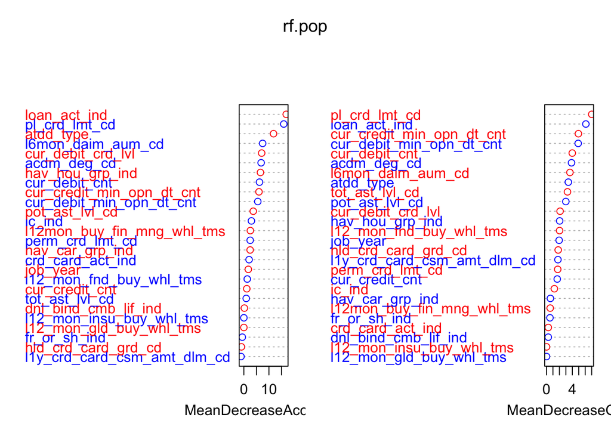

```r
varImpPlot(rf.pop, col=c("blue", "red"))
```

```r
rf.prob <- predict(rf.pop, dat.tf, type="prob")[,2]
```

We gathered the following statistics,

- merchant service charge, m = 0.8%
  - policy paper “中国银联入网机构银行卡跨行交易收益分配办法”
- interest rate charged per billing period, r0 = 1.5%
  - common practice among chinese banks
- interest rate at which lender can borrow money each period, r_f = 0.2%
  - convert annualised interest rate for one-year treasury bonds to monthly interest rate
- percentage final loss of balance at default on credit card, l_d = 70%
  - according to Bank of China annual report “2019 年资本充足率报告”
- average purchase per period using credit card, P = 590
  - calculated based on figures (“total amount of loans from credit card” + “no. of circulating cards”) from CMB’s annual report 2019
- average repayment per period, C = 637
  - calculated based on “profits from interest” + “total amount of loans from credit card” + “no. of circulating cards” from CMB’s annual report
- average balance per period, B = 3147
  - calculated based on the assumption rB + P = C

```r
#assumptions
m = 0.8/100
r0 = 1.5/100
r_F = 0.2/100
l_D = 70/100
P = 590
C = 637
B = 3147
N = (B+C)/C #assume this to be constant when P changes
```

Set interest rate

```r
#present equation of expected profitability from
ind_exp_prof  <- function (r, p, P) {
  P*(m-1) + P*(1+r)^(N-1)*((1 - l_D + l_D * p^N)/((1+r_F)^N))
}

avg_prof <- function (r, p_list, P) {
  e_list = c()
  p_opt <- ((1-m) * (1+r_F)^N / (l_D * (1+r)^(N-1)) + (l_D-1)/l_D)^(1/N)
  for (i in p_list) {
    if (i > p_opt) {
      e_r <- ind_exp_prof(r, i, P)
      e_list <- c(e_list, e_r)
    }
  }
 return(mean(e_list))
}


avg_prof(r=r0, p_list=rf.prob, P=590) #38.8
```

```
## [1] 38.82119
```

```r
r1 = r0 * 0.7
avg_prof(r=r1, rf.prob, P=590*1.49) #38.9
```

```
## [1] 38.87756
```

```r
#r_seq = seq(r0, r1, by=0.001)
#e_seq = c()
```